# Executive Function Engagement as Experience-Dependent Control Learning

When can experience generate persistent differences in EF engagement?

Author

Affiliation

Kyuri Park

Computational Science Lab

Published

August 20, 2026

# Quick intro

This version asks a narrower question than the previous capacity-based model:

> **Can persistent differences in the propensity to engage executive function (EF) emerge through experience, without assuming stable differences in EF capacity?**

The model is intentionally minimal. We start from established theories of cognitive-control allocation and learning, then ask what happens when the same mechanisms are iterated over a developmental time horizon.

The core distinction is:

- **Fast process:** a moment-to-moment decision about whether EF is worth engaging.
- **Slow processes:** learned expectations about
  - the value of engaging EF, and
  - how effortful engaging EF feels.

This version deliberately removes from the core model:

- a separate EF capacity state $K(t)$;
- an explicit maturation term;
- an age-dependent growth-opportunity function;
- a built-in sensitive period;
- individual differences in starting capacity.

The first goal is to see what **experience-dependent control learning alone** can and cannot generate.

The key phenomena we want to test are:

1. **Developmental improvement:** average EF engagement increases over accumulated experience.
2. **Emerging individual differences:** initially similar children become more different over time.
3. **Persistent individual differences:** relative differences persist across developmental periods rather than simply reflecting momentary noise.
4. **Transient contextual fluctuations:** temporary stress can lower engagement and engagement can recover.
5. **Intervention timing:** test whether early support has stronger later consequences *without* assuming an age-dependent growth window.

**The logic of this version**

The aim is **not** to force all five phenomena to appear.

If a minimal model fails to generate a phenomenon, that is theoretically informative. We then add one mechanism at a time and ask what additional assumption is actually required.

# Relationship to established control models

## Expected Value of Control (EVC): the fast decision

The Expected Value of Control framework defines the value of a candidate control signal as its expected payoff minus the cost of exerting that control:

$$\mathrm{EVC}(\text{signal},\text{state})
=
\mathbb{E}[\mathrm{Payoff}\mid \text{signal},\text{state}]
-
\mathrm{Cost}(\text{signal}).$$

The expected payoff depends on possible outcomes, their probabilities, and their values.

Reference: [Shenhav, Botvinick, & Cohen (2013), *The Expected Value of Control*](https://pmc.ncbi.nlm.nih.gov/articles/PMC3767969/).

Our model is a deliberately simplified binary version of this idea. At each episode, the agent can either:

$$A_t=1 \quad \text{engage EF},$$

or

$$A_t=0 \quad \text{do not engage EF}.$$

Rather than solving over a continuous range of control signals, we model the difference in expected control value between engaging and not engaging.

## Learned Value of Control (LVOC): learning from experience

The Learned Value of Control model proposes that agents can learn to predict the value of candidate control signals from previous experience instead of recomputing the full control problem from scratch each time.

Reference: [Lieder, Shenhav, Musslick, & Griffiths (2018), *Rational metareasoning and the plasticity of cognitive control*](https://journals.plos.org/ploscompbiol/article?id=10.1371/journal.pcbi.1006043).

The full LVOC model uses a richer feature-based approximation to the value of control. We do **not** reproduce that full model here. Instead, we borrow its core principle:

> experienced outcomes update the expected value assigned to future control.

Our $V_t$ should therefore be interpreted as a simplified learned expected payoff of engaging EF, not as an implementation of the full LVOC algorithm.

## Learning Expected Value of Control (LEVC): practice changes the future agent

LEVC extends EVC to situations in which experience changes what the agent will be able to do later. In the original LEVC model, task-specific **automaticity** increases with experience. Higher automaticity means that the same level of performance can be achieved with less cognitive control.

References:

- [Masís, Musslick, & Cohen (2021), *The Value of Learning and Cognitive Control Allocation*](https://escholarship.org/uc/item/7w0223v0)
- [Masís Obando, Musslick, & Cohen (2025), *Learning expectations shape cognitive control allocation*](https://www.pnas.org/doi/10.1073/pnas.2416720122)

In the 2021 formulation, automaticity in a learnable task is assumed to increase with the number of times that task has been practiced:

$$\mathrm{automaticity}_{L}
=
\alpha_L n_{\mathrm{trials},L}
+
\mathrm{automaticity}_{0,L}.$$

Automaticity then changes the relationship between control intensity and accuracy: greater automaticity allows equal accuracy with less control.

This is closely related to the developmental mechanism we need, but it also creates an important distinction:

$$\text{control engagement}
\neq
\text{observed EF performance}.$$

A child may become better at a practiced task while requiring less control to perform it.

The practice-related cost rule can be rewritten in a more intuitive way. Instead of tracking how subjective effort cost decreases, we can equivalently track how much practice-related improvement has accumulated. In this representation, engaging EF increases a bounded practice state, with progressively smaller gains as the child approaches the maximum amount of practice-related improvement. This does not add a new mechanism; it is simply another way of writing the same cost dynamics. The resulting process is similar in spirit to LEVC, where practice increases task-specific automaticity, but our model does not explicitly model automaticity or task performance. We therefore interpret this state more generally as accumulated practice or learned efficiency.

## Empirical precedent for learned control allocation

Bustamante et al. showed that learned stimulus-control associations can generalize and lead participants to exert control even when that amount of control is no longer required.

Reference: [Bustamante, Lieder, Musslick, Shenhav, & Cohen (2021), *Learning to Overexert Cognitive Control in a Stroop Task*](https://doi.org/10.3758/s13415-020-00845-x).

This does not establish our developmental cost-learning mechanism directly, but it supports the broader premise that control allocation itself can become experience-dependent and persistent.

# What is new here?

EVC, LVOC, and LEVC focus primarily on how control is allocated and learned within task environments.

Our question is different:

> **What happens to a population when experience-dependent control learning is iterated over a much longer developmental horizon?**

In particular:

> Can small differences in early experience produce later, persistent differences in EF engagement even when children begin with the same model parameters and no capacity differences?

# Core model

At each episode, the child implicitly evaluates:

> **Is engaging EF worth it right now?**

**Colors indicate the role of each component:** orange = slow learned states; green = momentary decision value; blue = fast engagement process; purple = experienced outcome; dashed gray = external context or environment.

```
%%{init: {"theme":"base","themeVariables":{"fontFamily":"Inter, system-ui, Arial"}}}%%
flowchart TB

classDef fast fill:#E8F4FF,stroke:#1E6FB9,stroke-width:1.5px,color:#0B2A3D;
classDef slow fill:#FFF2CC,stroke:#B07D00,stroke-width:1.5px,color:#3D2B00;
classDef outcome fill:#F3E8FF,stroke:#6B21A8,stroke-width:1.5px,color:#2E1065;
classDef decision fill:#E6FFFA,stroke:#0F766E,stroke-width:1.5px,color:#042F2E;
classDef context fill:#F3F4F6,stroke:#6B7280,stroke-width:1.2px,color:#111827,stroke-dasharray: 4 3;

linkStyle default stroke:#93A1AA,stroke-width:1.2px;

V(["V(t): learned value<br/>How much does EF usually pay off?"]):::slow
C(["C(t): learned effort cost<br/>How hard does engaging EF feel?"]):::slow
X[["Temporary context / stress"]]:::context

U{{"Net value of engaging EF"}}:::decision

P(["π(t): likelihood of engaging EF"]):::fast
A(["A(t): engage EF or not"]):::fast

ENV[["Reward environment<br/>How often does EF pay off?"]]:::context
R(["Experienced outcome"]):::outcome

V -->|"increases"| U
C -->|"decreases"| U
X -->|"temporarily decreases"| U

U --> P
P --> A

A -->|"creates experience"| R
ENV -->|"shapes payoff"| R

R -->|"learn whether EF pays off"| V
A -->|"practice makes future engagement easier"| C
```

The model separates a **propensity** from an **actual decision**:

$$\pi_t = \text{probability of engaging EF}$$

and

$$A_t \in \{0,1\} = \text{actual engagement on that episode}.$$

Learning occurs from the actual experience $A_t$, not from a fractional expected engagement value. This is important for the developmental question because two initially identical children can receive different sequences of engagement and reward outcomes simply through stochastic experience.

## 1. Fast control decision

For child $i$ at episode $t$, define the difference in expected value between engaging and not engaging EF as

$$\Delta \widehat{\mathrm{EVC}}_{i,t}
=
V_{i,t}
-
C_{i,t}
-
X_{i,t},$$

where:

- $V_{i,t}$ is the learned expected payoff of engaging EF;
- $C_{i,t}$ is the subjective effort cost;
- $X_{i,t}$ is temporary contextual cost, such as acute stress.

We map this value difference onto a probability of engagement:

$$\pi_{i,t}
=
\sigma\left(
\frac{\Delta \widehat{\mathrm{EVC}}_{i,t}}{\tau}
\right),$$

where

$$\sigma(x)=\frac{1}{1+e^{-x}}.$$

Actual engagement is stochastic:

$$A_{i,t}
\sim
\mathrm{Bernoulli}(\pi_{i,t}).$$

The temperature parameter $\tau$ controls how sharply value differences translate into behavior.

**Relation to canonical EVC**

This is not the full EVC optimization problem. It is a binary stochastic simplification in which the alternative “do not engage” option is treated as the reference level.

A later extension could make the alternative option explicit and learn the values of both engaging and not engaging EF.

## 2. Experienced reward

If EF is engaged, it can pay off with probability $p_{i,t}$:

$$Y_{i,t}
\sim
\mathrm{Bernoulli}(p_{i,t}).$$

The experienced reward is

$$R_{i,t}
=
A_{i,t}Y_{i,t}R,$$

where $R$ is reward magnitude.

If EF is not engaged, the agent receives no new evidence about the payoff from engaging EF in this minimal version.

## 3. Learned expected payoff

We use a simple delta-learning rule:

$$V_{i,t+1}
=
V_{i,t}
+
\alpha_V A_{i,t}
\left(
R_{i,t}-V_{i,t}
\right).$$

So:

- successful engagement can increase learned value;
- unsuccessful engagement can decrease learned value;
- not engaging produces no direct value update.

This is an LVOC-inspired simplification, not a reproduction of the full LVOC learning rule.

## 4. Practice-dependent effective effort cost

The cost-side hypothesis is that **actually engaging EF creates practice**, and practice can make the same kind of control easier to deploy later. Non-engagement is therefore a lost practice opportunity rather than an event that directly makes EF harder.

We start with the following reduced-form equation:

$$C_{i,t+1}
=
C_{i,t}
-
\alpha_C A_{i,t}
\left(
C_{i,t}-C_{\min}
\right).$$

Thus:

- engaging EF moves effective subjective cost toward a lower bound $C_{\min}$;
- not engaging EF does not directly increase cost;
- the size of the practice effect shrinks as there is less remaining room for improvement.

### The cost rule can be represented as bounded practice accumulation

The main theoretical concern with this equation is whether we are simply *assuming* that engagement lowers cost. It helps to reparameterize it.

Let

$$H_C=C_0-C_{\min}$$

denote the initial amount of cost reduction that is available through practice, and define a normalized practice/learned-efficiency state

$$L_{i,t}
=
\frac{C_0-C_{i,t}}{H_C}.$$

Then $L=0$ corresponds to the initial effort level and $L=1$ corresponds to the practice limit $C_{\min}$.

Starting from

$$C_{i,t+1}-C_{\min}
=
(C_{i,t}-C_{\min})
(1-\alpha_C A_{i,t}),$$

the same dynamics can be written as

$$\boxed{
L_{i,t+1}
=
L_{i,t}
+
\alpha_C A_{i,t}(1-L_{i,t})
}$$

with

$$C_{i,t}
=
C_{\min}
+
H_C(1-L_{i,t}).$$

So the same reduced-form dynamics can be represented in two mathematically equivalent ways:

$$\text{practice}
\rightarrow
C_t\downarrow$$

or

$$\text{practice}
\rightarrow
L_t\uparrow
\rightarrow
\text{effective effort required later}\downarrow.$$

The second representation gives the state a possible **practice/learned-efficiency interpretation** and is close in spirit to LEVC. LEVC assumes that automaticity increases with task experience and that greater automaticity allows equal performance with less control. Our model differs in two important ways:

1. LEVC’s illustrative learning rule is linear in accumulated task trials, whereas we use a **bounded, saturating** process because we iterate it over a long developmental horizon.
2. LEVC explicitly maps automaticity and continuous control intensity onto task accuracy. We collapse that relationship into a single **effective effort-cost state** because the current outcome is engagement propensity, not task performance.

For the engagement-only model, adding both $C_t$ and $L_t$ would therefore duplicate the same state. A separate automaticity state becomes necessary only if we later model **observed EF performance** explicitly.

**What $C_t$ means in the current model**

$C_t$ should not be read as a direct reinforcement-learning estimate of “how effortful the last attempt felt.”

It is a **reduced-form effective effort cost** that can decrease through accumulated practice. Reward outcomes update $V_t$; practice history changes $C_t$.

This distinction matters because the developmental result turns out to depend much more strongly on the practice pathway than on value learning alone.

The reinforcing loop is

$$A_t\uparrow
\rightarrow
L_{t+1}\uparrow
\rightarrow
C_{t+1}\downarrow
\rightarrow
\pi_{t+1}\uparrow
\rightarrow
A_{t+1}\uparrow.$$

Together with value learning:

$$A_t
\rightarrow
R_t
\rightarrow
V_{t+1}
\rightarrow
\pi_{t+1}.$$

# Why differentiation grows and then weakens

The simulations are easier to interpret if we first write the feedback in terms of one quantity.

Ignoring temporary context for the moment, define

$$D_t=V_t-C_t.$$

$D_t$ is the learned net advantage of engaging EF before the logistic decision rule is applied:

$$\pi_t
=
\sigma\left(
\frac{D_t}{\tau}
\right).$$

Under a stationary reward environment with reward probability $p$,

$$\mathbb{E}[\Delta V_t\mid V_t,C_t]
=
\alpha_V\pi_t(pR-V_t)$$

and

$$\mathbb{E}[\Delta C_t\mid V_t,C_t]
=
-\alpha_C\pi_t(C_t-C_{\min}).$$

Therefore,

$$\boxed{
\mathbb{E}[\Delta D_t\mid V_t,C_t]
=
\pi_t
\left[
\alpha_V(pR-V_t)
+
\alpha_C(C_t-C_{\min})
\right].
}$$

Define the term in brackets as the remaining **learning headroom**:

$$H_t
=
\alpha_V(pR-V_t)
+
\alpha_C(C_t-C_{\min}).$$

When

$$V_t<pR
\qquad\text{and}\qquad
C_t>C_{\min},$$

we have $H_t>0$. A child who happens to have slightly larger $D_t$ has a larger engagement probability $\pi_t$, and therefore receives the value-learning and practice updates more often:

$$D_t\uparrow
\Rightarrow
\pi_t\uparrow
\Rightarrow
\text{more updating}
\Rightarrow
D_{t+1}\uparrow.$$

This is the reinforcing mechanism that can generate developmental differentiation in the model.

Importantly, the equation does **not** imply that any child who is slightly ahead must deterministically move farther ahead. A higher $\pi_t$ creates more opportunities for learning and practice, but a child who is farther along can also have less remaining headroom. The simulations therefore test whether the reinforcing difference in **learning opportunity** is strong enough to produce population-level differentiation under a given parameterization.

The same equation also explains why the differentiation is self-limiting. As learning accumulates,

$$V_t\rightarrow pR
\qquad\text{and}\qquad
C_t\rightarrow C_{\min},$$

so

$$H_t\rightarrow0.$$

The reinforcing advantage of being slightly ahead therefore becomes weaker as there is less left to learn.

**What this does and does not prove**

This argument identifies the **local reinforcing mechanism in learning opportunity**. It does not imply that every possible parameterization must generate large or persistent individual differences.

How much differentiation appears depends on the learning rates, decision temperature, initial net value, available practice headroom, and time horizon. We test that dependence explicitly in the replicated parameter analysis below.

## Common long-run regime

The mean deterministic tendencies are toward

$$V^*=pR$$

and

$$C^*=C_{\min}.$$

The corresponding common mean-control regime is

$$\pi^*
=
\sigma\left(
\frac{pR-C_{\min}}{\tau}
\right).$$

This common regime applies when children share the same stationary reward environment. If reward probability differs persistently across children, $p_i$, then

$$V_i^*=p_iR,
\qquad
C_i^*=C_{\min},$$

and the corresponding long-run mean engagement levels can also differ:

$$\pi_i^*
=
\sigma\left(
\frac{p_iR-C_{\min}}{\tau}
\right).$$

So the model distinguishes two sources of developmental differentiation:

- **stochastic history under a shared environment** can make initially identical children diverge over a developmental horizon;
- **persistent environmental differences** can additionally anchor different long-run mean engagement levels.

Because the simulations retain stochastic choices and reward outcomes with a constant learning rate, individual trajectories need not collapse to a single point. They can continue to fluctuate around this common regime.

The stronger developmental questions are therefore:

1. **Finite developmental differentiation:** can early stochastic experience create large differences over a developmentally relevant horizon?
2. **Rank persistence:** do the same children remain relatively high or low, or does that ordering eventually disappear?
3. **Environmental anchoring:** can small persistent differences in reward environments stabilize which children remain relatively high or low?

This distinction prevents us from calling finite-horizon differentiation a set of permanently distinct asymptotic states.

# Model ladder

Rather than fitting one large model, we compare nested versions.

| Model | Fast EVC-like choice | Learned value | Practice lowers cost | Passive cost stabilization |
| --- | --- | --- | --- | --- |
| M0: EVC only | yes | no | no | no |
| M1: + value learning | yes | yes | no | no |
| M2: + practice-cost feedback | yes | yes | yes | no |
| M3: + cost stabilization | yes | yes | yes | yes |

The core paper should initially focus on M0-M2.

M3 is included as a diagnostic extension because Yuko previously asked whether a baseline cost level / mean-reversion term is actually necessary.

# Simulation setup

## General choices

These are qualitative simulations, not fitted developmental estimates.

- Time is measured in **developmental episodes**, not literal weeks or years.
- For figures, time is normalized to $[0,1]$.
- All agents have identical starting $V_0$ and $C_0$ in the primary analyses.
- All agents have identical learning parameters.
- Stochasticity comes from actual engagement decisions and reward outcomes.
- We later introduce a *very small* between-child difference in reward probability as an environmental heterogeneity test.

**Parameter status**

The default parameters below are provisional. They are chosen to keep the system away from immediate floor/ceiling behavior so that the qualitative dynamics are visible, not as empirical estimates.

```r
clip <- function(x, lo = 0, hi = 1) {
  pmin(pmax(x, lo), hi)
}

default_pars <- list(
  N = 800,
  T = 1500,

  # Identical initial states
  V0 = 0.577,
  C0 = 0.987,

  # Fast control decision
  tau = 0.163,

  # Reward environment
  p_reward = 0.591,
  reward_mag = 1.150,

  # Learning
  alpha_V = 0.0244,
  alpha_C = 0.00263,
  C_min = 0.459,

  # Optional cost stabilization (M3 only)
  C_set = 0.987,
  eta_C = 0.0008,

  record_every = 5
)

model_labels <- c(
  evc = "M0: EVC only",
  value = "M1: + learned value",
  value_cost = "M2: + practice feedback",
  value_cost_stabilized = "M3: + cost stabilization"
)

model_cols <- c(
  "M0: EVC only" = "#6B7280",
  "M1: + learned value" = "#4C78A8",
  "M2: + practice feedback" = "#2A9D8F",
  "M3: + cost stabilization" = "#B56576"
)

condition_cols <- c(
  "Reference" = "#4B5563",
  "Stress" = "#B54A4A",
  "Early support" = "#2A9D8F",
  "Later support" = "#D96C4A",
  "Identical environment" = "#4C78A8",
  "Tiny reward differences" = "#B56576"
)

snapshot_cols <- c(
  "Early" = "#B56576",
  "Middle" = "#6A994E",
  "Late" = "#4E79A7"
)

theme_result <- function(base_size = 14) {
  theme_minimal(base_size = base_size) +
    theme(
      legend.position = "bottom",
      panel.grid.minor = element_blank(),
      plot.title.position = "plot",
      plot.title = element_text(
        face = "bold",
        size = base_size,
        margin = margin(b = 7)
      ),
      plot.subtitle = element_text(
        size = base_size - 2,
        margin = margin(b = 6)
      ),
      axis.title.y = element_text(
        margin = margin(r = 12)
      ),
      axis.title.x = element_text(
        margin = margin(t = 8)
      ),
      strip.text = element_text(face = "bold"),
      plot.margin = margin(14, 26, 14, 34)
    )
}

scale_dev_time <- function() {
  scale_x_continuous(
    limits = c(0, 1),
    breaks = seq(0, 1, by = 0.25),
    expand = expansion(mult = c(0.005, 0.005))
  )
}
```

```r
simulate_population <- function(
  model = c("evc", "value", "value_cost", "value_cost_stabilized"),

  N = default_pars$N,
  T = default_pars$T,

  V0 = default_pars$V0,
  C0 = default_pars$C0,

  tau = default_pars$tau,

  p_reward = default_pars$p_reward,
  p_reward_sd = 0,
  reward_mag = default_pars$reward_mag,

  alpha_V = default_pars$alpha_V,
  alpha_C = default_pars$alpha_C,
  C_min = default_pars$C_min,

  C_set = default_pars$C_set,
  eta_C = default_pars$eta_C,

  p_reward_shift = NULL,
  extra_cost = NULL,

  record_every = default_pars$record_every,
  seed = 1
) {

  model <- match.arg(model)

  stopifnot(N >= 2, T >= 2, tau > 0)
  stopifnot(alpha_V >= 0, alpha_C >= 0, eta_C >= 0)
  stopifnot(C_min < C0)

  if (is.null(p_reward_shift)) p_reward_shift <- rep(0, T)
  if (is.null(extra_cost)) extra_cost <- rep(0, T)

  stopifnot(length(p_reward_shift) == T)
  stopifnot(length(extra_cost) == T)

  set.seed(seed)

  child_id <- seq_len(N)

  # Primary analyses use p_reward_sd = 0.
  # A later analysis introduces a very small persistent environmental difference.
  p_i <- clip(rnorm(N, mean = p_reward, sd = p_reward_sd))

  V <- rep(V0, N)
  C <- rep(C0, N)

  out <- vector("list", ceiling(T / record_every) + 2)
  k <- 1

  for (tt in seq_len(T)) {

    p_t <- clip(p_i + p_reward_shift[tt])

    delta_evc <- V - C - extra_cost[tt]
    pi_engage <- plogis(delta_evc / tau)

    # Actual engagement decision.
    A <- as.integer(runif(N) < pi_engage)

    # Potential reward outcome. It only enters learning when A = 1.
    reward_success <- as.integer(runif(N) < p_t)
    reward_observed <- A * reward_success * reward_mag

    if (tt == 1 || tt %% record_every == 0 || tt == T) {
      out[[k]] <- tibble(
        child_id = child_id,
        step = tt,
        dev_time = (tt - 1) / (T - 1),

        p_reward_child = p_i,
        p_reward_used = p_t,
        extra_cost = extra_cost[tt],

        V = V,
        C = C,
        effective_cost = C + extra_cost[tt],

        delta_evc = delta_evc,
        pi = pi_engage,
        A = A,
        reward = reward_observed
      )

      k <- k + 1
    }

    # M1-M3: learn expected payoff from actual engagement outcomes.
    if (model %in% c("value", "value_cost", "value_cost_stabilized")) {
      V <- V + alpha_V * A * (reward_observed - V)
    }

    # M2-M3: actual engagement gradually lowers subjective effort cost.
    if (model %in% c("value_cost", "value_cost_stabilized")) {
      C <- C - alpha_C * A * (C - C_min)
    }

    # M3 only: passive return toward a baseline cost level.
    # This is tested as an additional mechanism, not assumed in the core model.
    if (model == "value_cost_stabilized") {
      C <- C + eta_C * (C_set - C)
    }

    # Numerical bounds.
    V <- clip(V, lo = 0, hi = reward_mag)
    C <- pmax(C, C_min)
  }

  bind_rows(out[seq_len(k - 1)]) %>%
    mutate(
      model = model,
      model_label = unname(model_labels[model])
    )
}
```

```r
population_summary <- function(df) {
  df %>%
    group_by(model_label, dev_time) %>%
    summarize(
      mean_pi = mean(pi),
      sd_pi = sd(pi),
      mean_V = mean(V),
      mean_C = mean(C),
      mean_A = mean(A),
      .groups = "drop"
    )
}

window_score <- function(df, lo, hi, label) {
  df %>%
    filter(dev_time >= lo, dev_time <= hi) %>%
    group_by(child_id) %>%
    summarize(
      score = mean(pi),
      .groups = "drop"
    ) %>%
    mutate(window = label)
}

stability_table <- function(df) {

  scores <- bind_rows(
    window_score(df, 0.20, 0.30, "Early"),
    window_score(df, 0.50, 0.60, "Middle"),
    window_score(df, 0.85, 0.95, "Late")
  ) %>%
    pivot_wider(
      names_from = window,
      values_from = score
    )

  tibble(
    comparison = c(
      "Early vs Middle",
      "Middle vs Late",
      "Early vs Late"
    ),
    spearman_rho = suppressWarnings(c(
      cor(scores$Early, scores$Middle, method = "spearman"),
      cor(scores$Middle, scores$Late, method = "spearman"),
      cor(scores$Early, scores$Late, method = "spearman")
    ))
  )
}

development_metrics <- function(df) {

  early <- df %>% filter(dev_time >= 0.05, dev_time <= 0.15)
  late  <- df %>% filter(dev_time >= 0.85, dev_time <= 0.95)

  early_sd <- early %>%
    group_by(dev_time) %>%
    summarize(x = sd(pi), .groups = "drop") %>%
    summarize(x = mean(x, na.rm = TRUE)) %>%
    pull(x)

  late_sd <- late %>%
    group_by(dev_time) %>%
    summarize(x = sd(pi), .groups = "drop") %>%
    summarize(x = mean(x, na.rm = TRUE)) %>%
    pull(x)

  stab <- stability_table(df)

  tibble(
    early_mean = mean(early$pi),
    late_mean = mean(late$pi),
    delta_mean = late_mean - early_mean,
    early_sd = early_sd,
    late_sd = late_sd,
    sd_gain = late_sd - early_sd,
    rho_middle_late = stab$spearman_rho[stab$comparison == "Middle vs Late"],
    rho_early_late = stab$spearman_rho[stab$comparison == "Early vs Late"]
  )
}

get_snapshot <- function(df, target, label) {
  df %>%
    group_by(child_id) %>%
    slice_min(
      order_by = abs(dev_time - target),
      n = 1,
      with_ties = FALSE
    ) %>%
    ungroup() %>%
    mutate(snapshot = label)
}

# Lightweight simulator for parameter sweeps.
# It computes only the early/middle/late summaries needed by
# development_metrics(), rather than constructing a full trajectory tibble.
simulate_development_metrics_fast <- function(
  N,
  T,
  V0,
  C0,
  tau,
  p_reward,
  reward_mag = default_pars$reward_mag,
  alpha_V,
  alpha_C,
  C_min,
  record_every = 10,
  seed = 1
) {

  set.seed(seed)

  V <- rep(V0, N)
  C <- rep(C0, N)

  early_sum <- 0
  late_sum <- 0
  early_n <- 0L
  late_n <- 0L

  early_sd_sum <- 0
  late_sd_sum <- 0
  early_sd_n <- 0L
  late_sd_n <- 0L

  early_child_sum <- numeric(N)
  middle_child_sum <- numeric(N)
  late_child_sum <- numeric(N)

  early_child_n <- 0L
  middle_child_n <- 0L
  late_child_n <- 0L

  for (tt in seq_len(T)) {

    dev_time <- (tt - 1) / (T - 1)

    pi_engage <- plogis((V - C) / tau)

    record_this <- (
      tt == 1 ||
      tt %% record_every == 0 ||
      tt == T
    )

    if (record_this) {

      if (dev_time >= 0.05 && dev_time <= 0.15) {
        early_sum <- early_sum + sum(pi_engage)
        early_n <- early_n + N
        early_sd_sum <- early_sd_sum + sd(pi_engage)
        early_sd_n <- early_sd_n + 1L
        early_child_sum <- early_child_sum + pi_engage
        early_child_n <- early_child_n + 1L
      }

      if (dev_time >= 0.50 && dev_time <= 0.60) {
        middle_child_sum <- middle_child_sum + pi_engage
        middle_child_n <- middle_child_n + 1L
      }

      if (dev_time >= 0.85 && dev_time <= 0.95) {
        late_sum <- late_sum + sum(pi_engage)
        late_n <- late_n + N
        late_sd_sum <- late_sd_sum + sd(pi_engage)
        late_sd_n <- late_sd_n + 1L
        late_child_sum <- late_child_sum + pi_engage
        late_child_n <- late_child_n + 1L
      }
    }

    A <- as.integer(runif(N) < pi_engage)
    reward_success <- as.integer(runif(N) < p_reward)
    reward_observed <- A * reward_success * reward_mag

    V <- V + alpha_V * A * (reward_observed - V)
    C <- C - alpha_C * A * (C - C_min)

    V <- clip(V, lo = 0, hi = reward_mag)
    C <- pmax(C, C_min)
  }

  early_scores <- early_child_sum / early_child_n
  middle_scores <- middle_child_sum / middle_child_n
  late_scores <- late_child_sum / late_child_n

  early_mean <- early_sum / early_n
  late_mean <- late_sum / late_n
  early_sd <- early_sd_sum / early_sd_n
  late_sd <- late_sd_sum / late_sd_n

  tibble(
    early_mean = early_mean,
    late_mean = late_mean,
    delta_mean = late_mean - early_mean,
    early_sd = early_sd,
    late_sd = late_sd,
    sd_gain = late_sd - early_sd,
    rho_middle_late = suppressWarnings(
      cor(middle_scores, late_scores, method = "spearman")
    ),
    rho_early_late = suppressWarnings(
      cor(early_scores, late_scores, method = "spearman")
    )
  )
}

rank_percentile <- function(x) {
  if (length(unique(x)) <= 1) return(rep(0.5, length(x)))
  dplyr::percent_rank(x)
}

# Fail loudly if a time-series plot is accidentally truncated or contains
# non-finite values. This is used before the main developmental figures.
assert_plot_coverage <- function(
  df,
  time_col = "dev_time",
  group_cols = character(0),
  value_cols = NULL,
  expected_start = 0,
  expected_end = 1,
  tolerance = 1e-6
) {

  stopifnot(time_col %in% names(df))

  if (length(group_cols) == 0) {
    ranges <- tibble(
      min_time = min(df[[time_col]], na.rm = TRUE),
      max_time = max(df[[time_col]], na.rm = TRUE)
    )
  } else {
    ranges <- df %>%
      group_by(across(all_of(group_cols))) %>%
      summarize(
        min_time = min(.data[[time_col]], na.rm = TRUE),
        max_time = max(.data[[time_col]], na.rm = TRUE),
        .groups = "drop"
      )
  }

  if (
    any(abs(ranges$min_time - expected_start) > tolerance) ||
    any(abs(ranges$max_time - expected_end) > tolerance)
  ) {
    stop("A plotted trajectory does not span the intended time range.")
  }

  if (!is.null(value_cols)) {
    bad <- vapply(
      value_cols,
      function(v) any(!is.finite(df[[v]])),
      logical(1)
    )
    if (any(bad)) {
      stop(
        "Non-finite values found in plotted variables: ",
        paste(value_cols[bad], collapse = ", ")
      )
    }
  }

  invisible(TRUE)
}

score_at_steps <- function(df, center_step, half_width) {
  df %>%
    filter(
      step >= center_step - half_width,
      step <= center_step + half_width
    ) %>%
    group_by(child_id) %>%
    summarize(score = mean(pi), .groups = "drop")
}
```

# Result 1: Practice feedback changes the developmental dynamics

We first compare nested models using agents who are **identical at baseline and share the same reward environment**. The point is to identify which mechanism is actually responsible for developmental change and differentiation.

```r
core_models <- c(
  "evc",
  "value",
  "value_cost"
)

df_models <- bind_rows(
  lapply(seq_along(core_models), function(j) {
    simulate_population(
      model = core_models[j],
      p_reward_sd = 0,
      seed = 4100
    )
  })
)

summary_models <- population_summary(df_models)

assert_plot_coverage(
  summary_models,
  group_cols = "model_label",
  value_cols = c("mean_pi", "sd_pi")
)

model_metrics <- bind_rows(
  lapply(split(df_models, df_models$model_label), function(x) {
    development_metrics(x)
  }),
  .id = "model_label"
)
```

## Population mean and between-child heterogeneity

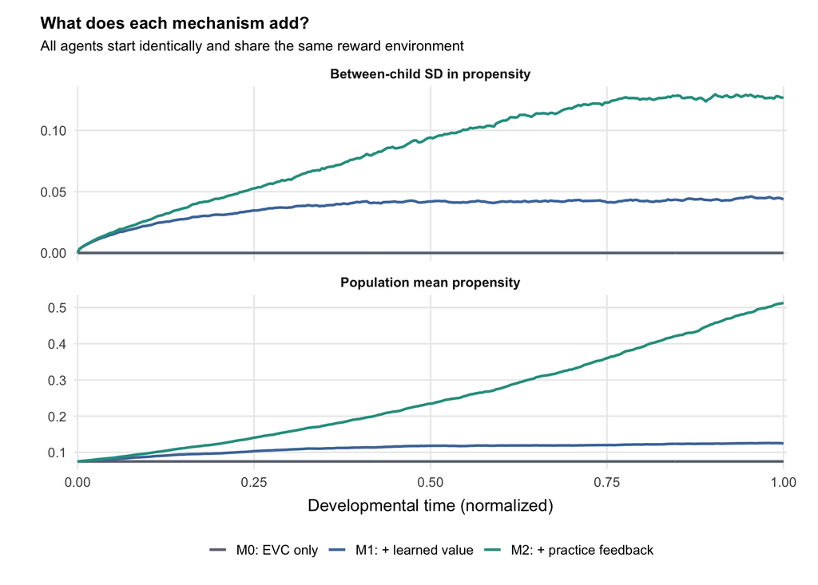

```r
nested_plot_df <- summary_models %>%
  select(model_label, dev_time, mean_pi, sd_pi) %>%
  pivot_longer(
    cols = c(mean_pi, sd_pi),
    names_to = "measure",
    values_to = "value"
  ) %>%
  mutate(
    measure = recode(
      measure,
      mean_pi = "Population mean propensity",
      sd_pi = "Between-child SD in propensity"
    )
  )

ggplot(
  nested_plot_df,
  aes(dev_time, value, color = model_label)
) +
  geom_line(linewidth = 1.05) +
  facet_wrap(~ measure, ncol = 1, scales = "free_y") +
  scale_color_manual(values = model_cols) +
  scale_dev_time() +
  theme_result() +
  labs(
    title = "What does each mechanism add?",
    subtitle = "All agents start identically and share the same reward environment",
    x = "Developmental time (normalized)",
    y = NULL,
    color = NULL
  )
```

Developmental change, heterogeneity, and rank persistence by model

| model_label | early_mean | late_mean | early_sd | late_sd | rho_middle_late |
| --- | --- | --- | --- | --- | --- |
| M0: EVC only | 0.075 | 0.075 | 0.000 | 0.000 | NA |
| M1: + learned value | 0.088 | 0.124 | 0.022 | 0.044 | 0.274 |
| M2: + practice feedback | 0.098 | 0.455 | 0.027 | 0.127 | 0.574 |

With the current provisional parameters, **EVC alone is flat**, as expected: there is no learning mechanism that could generate developmental change. Adding learned value produces some change, but the much larger shift appears after adding the practice feedback. In M2, children who happen to engage slightly more receive more opportunities both to update value and to reduce future subjective cost.

The reinforcing part of the mechanism is

$$\pi_t\uparrow
\rightarrow
A_t\uparrow
\rightarrow
\begin{cases}
\text{more reward-learning opportunities}\\
\text{more practice-related cost reduction}
\end{cases}
\rightarrow
\pi_{t+1}\uparrow.$$

This does **not** imply unlimited divergence. As value and cost approach the amounts left to learn, the feedback weakens.

# Result 2: Initially identical children differentiate over development

This is the strictest emergence test. Everyone has

$$V_{i,0}=V_0,
\qquad
C_{i,0}=C_0,
\qquad
p_i=p.$$

The only source of between-child differences is the stochastic sequence of (1) whether EF is actually engaged and (2) whether engagement pays off.

```r
df_identical <- simulate_population(
  model = "value_cost",
  N = 1000,
  p_reward_sd = 0,
  seed = 20260819
)

metrics_identical <- development_metrics(df_identical)
stability_identical <- stability_table(df_identical)
```

## Example individual trajectories

A population summary can hide the fact that the model is producing genuinely different developmental paths. The next figure shows a small representative subset from the **identical-start, identical-environment** simulation.

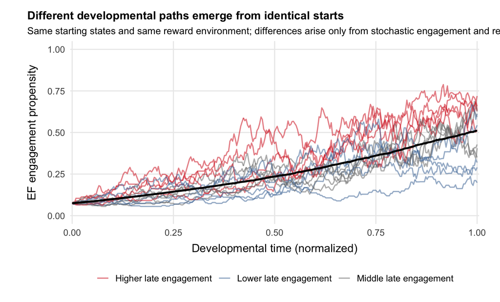

```r
late_groups_identical <- df_identical %>%
  filter(dev_time >= 0.85, dev_time <= 0.95) %>%
  group_by(child_id) %>%
  summarize(
    late_pi = mean(pi),
    .groups = "drop"
  ) %>%
  mutate(
    late_group = case_when(
      late_pi <= quantile(late_pi, 1/3) ~ "Lower late engagement",
      late_pi >= quantile(late_pi, 2/3) ~ "Higher late engagement",
      TRUE ~ "Middle late engagement"
    )
  )

set.seed(20260820)

sample_n_safe <- function(df, k = 5) {
  dplyr::slice_sample(
    df,
    n = min(k, nrow(df))
  )
}

sampled_children <- bind_rows(
  late_groups_identical %>%
    filter(late_group == "Lower late engagement") %>%
    sample_n_safe(5),
  late_groups_identical %>%
    filter(late_group == "Middle late engagement") %>%
    sample_n_safe(5),
  late_groups_identical %>%
    filter(late_group == "Higher late engagement") %>%
    sample_n_safe(5)
)

trajectory_df <- df_identical %>%
  semi_join(sampled_children, by = "child_id") %>%
  left_join(
    sampled_children %>%
      select(child_id, late_group),
    by = "child_id"
  )

trajectory_mean <- df_identical %>%
  group_by(dev_time) %>%
  summarize(
    mean_pi = mean(pi),
    .groups = "drop"
  )

trajectory_cols <- c(
  "Lower late engagement" = "#4E79A7",
  "Middle late engagement" = "#7A7A7A",
  "Higher late engagement" = "#D62728"
)

ggplot(
  trajectory_df,
  aes(dev_time, pi, group = child_id, color = late_group)
) +
  geom_line(alpha = 0.55, linewidth = 0.70) +
  geom_line(
    data = trajectory_mean,
    aes(dev_time, mean_pi),
    inherit.aes = FALSE,
    color = "black",
    linewidth = 1.15
  ) +
  scale_color_manual(values = trajectory_cols) +
  scale_dev_time() +
  coord_cartesian(ylim = c(0, 1)) +
  theme_result() +
  labs(
    title = "Different developmental paths emerge from identical starts",
    subtitle = "Same starting states and same reward environment; differences arise only from stochastic engagement and reward history",
    x = "Developmental time (normalized)",
    y = "EF engagement propensity",
    color = NULL
  )
```

Even when every child begins with the same parameters and the same reward environment, stochastic engagement and reward histories generate visibly different developmental paths. These differences are substantial over the developmental horizon, although the shared-environment long-horizon analysis below shows that their identities are not permanently fixed.

## The population spreads out

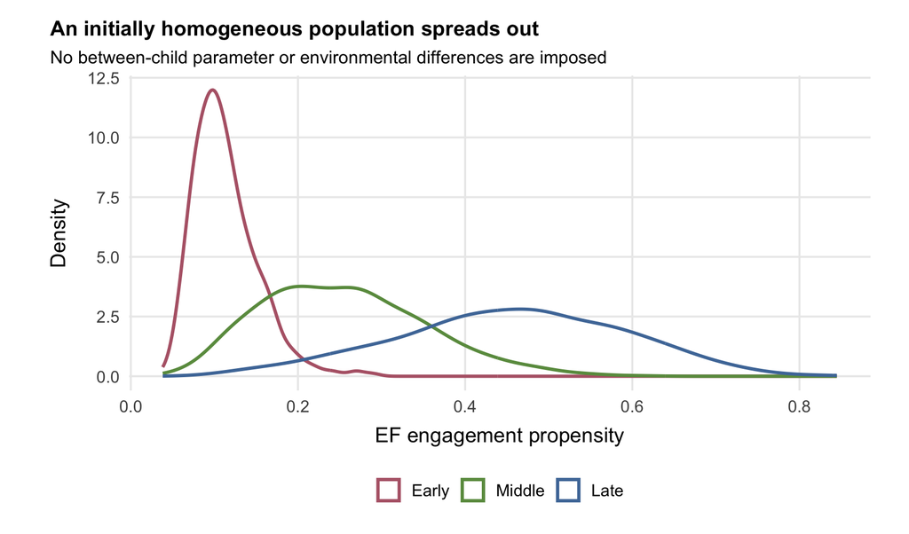

```r
snapshots <- bind_rows(
  get_snapshot(df_identical, 0.15, "Early"),
  get_snapshot(df_identical, 0.55, "Middle"),
  get_snapshot(df_identical, 0.90, "Late")
) %>%
  mutate(
    snapshot = factor(
      snapshot,
      levels = c("Early", "Middle", "Late")
    )
  )

ggplot(snapshots, aes(pi, color = snapshot)) +
  geom_density(linewidth = 1.05, adjust = 1.1) +
  scale_color_manual(values = snapshot_cols) +
  theme_result() +
  labs(
    title = "An initially homogeneous population spreads out",
    subtitle = "No between-child parameter or environmental differences are imposed",
    x = "EF engagement propensity",
    y = "Density",
    color = NULL
  )
```

The increase in dispersion is substantial over this developmental horizon. This establishes **heterogeneity**, but not yet permanent individual types.

## Relative differences are moderately persistent

Rank-order stability of EF engagement propensity

| comparison | spearman_rho |
| --- | --- |
| Early vs Middle | 0.524 |
| Middle vs Late | 0.616 |
| Early vs Late | 0.494 |

The rank correlations are moderate rather than close to 1. We therefore describe these differences as **developmentally persistent** or **moderately rank-stable**, not as permanently fixed individual differences.

### Rank-to-rank visualization

The previous propensity-versus-propensity scatter was dominated by the fact that the whole population improves. A percentile plot isolates the question we actually care about: whether children preserve their relative position.

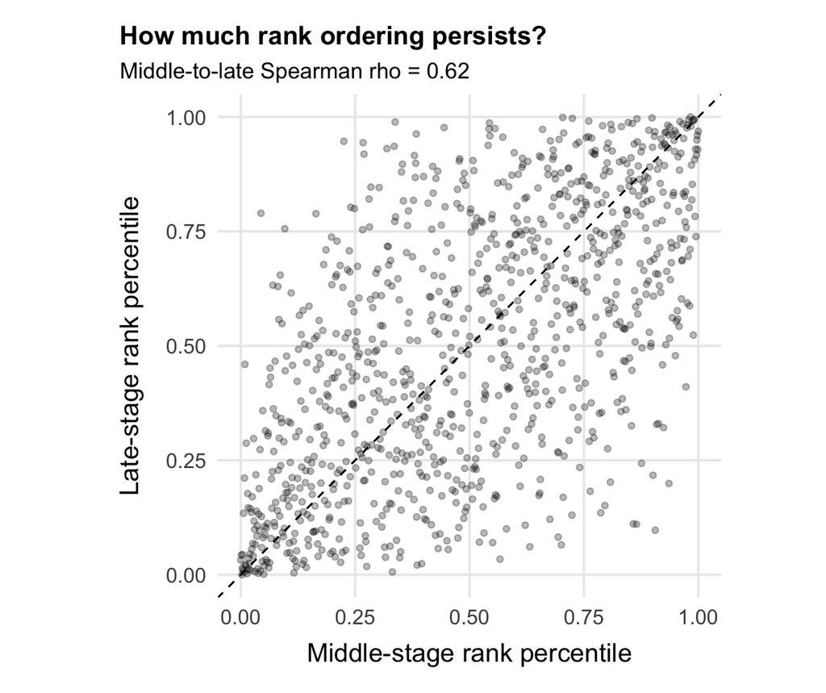

```r
scores_identical <- bind_rows(
  window_score(df_identical, 0.50, 0.60, "Middle"),
  window_score(df_identical, 0.85, 0.95, "Late")
) %>%
  pivot_wider(
    names_from = window,
    values_from = score
  ) %>%
  mutate(
    middle_rank = rank_percentile(Middle),
    late_rank = rank_percentile(Late)
  )

ggplot(scores_identical, aes(middle_rank, late_rank)) +
  geom_point(alpha = 0.28, size = 1.3) +
  geom_abline(linetype = "dashed", linewidth = 0.5) +
  coord_equal(xlim = c(0, 1), ylim = c(0, 1)) +
  theme_result() +
  labs(
    title = "How much rank ordering persists?",
    subtitle = paste0(
      "Middle-to-late Spearman rho = ",
      round(stability_identical$spearman_rho[
        stability_identical$comparison == "Middle vs Late"
      ], 2)
    ),
    x = "Middle-stage rank percentile",
    y = "Late-stage rank percentile"
  )
```

# Result 3: Persistent reward differences anchor later engagement differences

The developmental account does not require children’s environments to be identical. It proposes that environments differ in whether engaging EF tends to pay off.

Here we introduce only a **small** persistent difference in reward probability:

1. identical reward probability for everyone;
2. a narrow distribution with $SD(p_i)=0.02$ around the same mean.

No other between-child parameters are changed.

### Long-run trajectories under persistent environmental differences

The shared-environment simulation in Result 2 isolates differentiation generated by stochastic experience. We now ask what happens when children also experience a **small, persistent difference in how often engaging EF pays off**. The same narrow reward heterogeneity used in this section, $SD(p_i)=0.02$, is carried forward over a longer horizon.

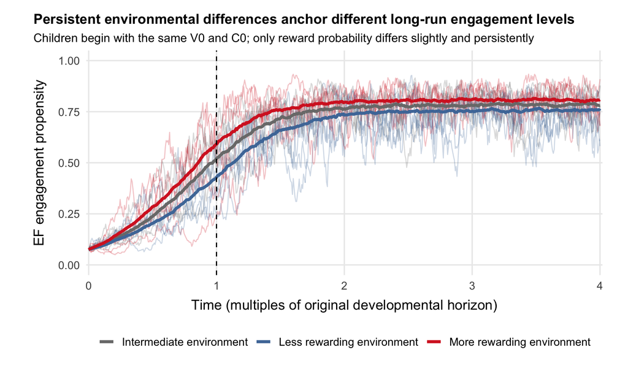

```r
T_long_env <- 4 * (default_pars$T - 1) + 1

df_environment_long <- simulate_population(
  model = "value_cost",
  N = 1000,
  T = T_long_env,
  p_reward_sd = 0.02,
  record_every = 10,
  seed = 601
) %>%
  mutate(
    time_multiple = (step - 1) / (default_pars$T - 1)
  )

environment_groups <- df_environment_long %>%
  distinct(
    child_id,
    p_reward_child
  ) %>%
  mutate(
    environment_group = case_when(
      p_reward_child <= quantile(p_reward_child, 1/3) ~
        "Less rewarding environment",
      p_reward_child >= quantile(p_reward_child, 2/3) ~
        "More rewarding environment",
      TRUE ~
        "Intermediate environment"
    )
  )

set.seed(20260820)

sampled_environment_children <- bind_rows(
  environment_groups %>%
    filter(environment_group == "Less rewarding environment") %>%
    sample_n_safe(5),
  environment_groups %>%
    filter(environment_group == "Intermediate environment") %>%
    sample_n_safe(5),
  environment_groups %>%
    filter(environment_group == "More rewarding environment") %>%
    sample_n_safe(5)
)

trajectory_environment <- df_environment_long %>%
  semi_join(
    sampled_environment_children,
    by = "child_id"
  ) %>%
  left_join(
    sampled_environment_children %>%
      select(
        child_id,
        environment_group
      ),
    by = "child_id"
  )

environment_group_mean <- df_environment_long %>%
  left_join(
    environment_groups,
    by = c(
      "child_id",
      "p_reward_child"
    )
  ) %>%
  group_by(
    environment_group,
    time_multiple
  ) %>%
  summarize(
    mean_pi = mean(pi),
    .groups = "drop"
  )

environment_cols <- c(
  "Less rewarding environment" = "#4E79A7",
  "Intermediate environment" = "#7A7A7A",
  "More rewarding environment" = "#D62728"
)

ggplot(
  trajectory_environment,
  aes(
    time_multiple,
    pi,
    group = child_id,
    color = environment_group
  )
) +
  geom_line(
    alpha = 0.26,
    linewidth = 0.48
  ) +
  geom_line(
    data = environment_group_mean,
    aes(
      time_multiple,
      mean_pi,
      color = environment_group,
      group = environment_group
    ),
    inherit.aes = FALSE,
    linewidth = 1.45
  ) +
  geom_vline(
    xintercept = 1,
    linetype = "dashed",
    linewidth = 0.55
  ) +
  scale_color_manual(values = environment_cols) +
  scale_x_continuous(
    limits = c(0, 4),
    breaks = 0:4,
    expand = expansion(mult = c(0.005, 0.005))
  ) +
  coord_cartesian(ylim = c(0, 1)) +
  theme_result() +
  labs(
    title = "Persistent environmental differences anchor different long-run engagement levels",
    subtitle = "Children begin with the same V0 and C0; only reward probability differs slightly and persistently",
    x = "Time (multiples of original developmental horizon)",
    y = "EF engagement propensity",
    color = NULL
  )
```

The individual paths remain stochastic, but the group averages settle into different long-run mean regimes. This is the model’s **environmental anchoring** mechanism: persistent differences in how often control pays off can maintain different engagement levels without requiring different EF capacities.

```r
df_context_same <- simulate_population(
  model = "value_cost",
  N = 1000,
  p_reward_sd = 0,
  seed = 601
) %>%
  mutate(context_condition = "Identical environment")

df_context_tiny <- simulate_population(
  model = "value_cost",
  N = 1000,
  p_reward_sd = 0.02,
  seed = 601
) %>%
  mutate(context_condition = "Tiny reward differences")

df_context <- bind_rows(
  df_context_same,
  df_context_tiny
)

context_metrics <- bind_rows(
  development_metrics(df_context_same) %>%
    mutate(context_condition = "Identical environment"),
  development_metrics(df_context_tiny) %>%
    mutate(context_condition = "Tiny reward differences")
)

context_stability <- bind_rows(
  stability_table(df_context_same) %>%
    mutate(context_condition = "Identical environment"),
  stability_table(df_context_tiny) %>%
    mutate(context_condition = "Tiny reward differences")
)
```

## They modestly widen the distribution

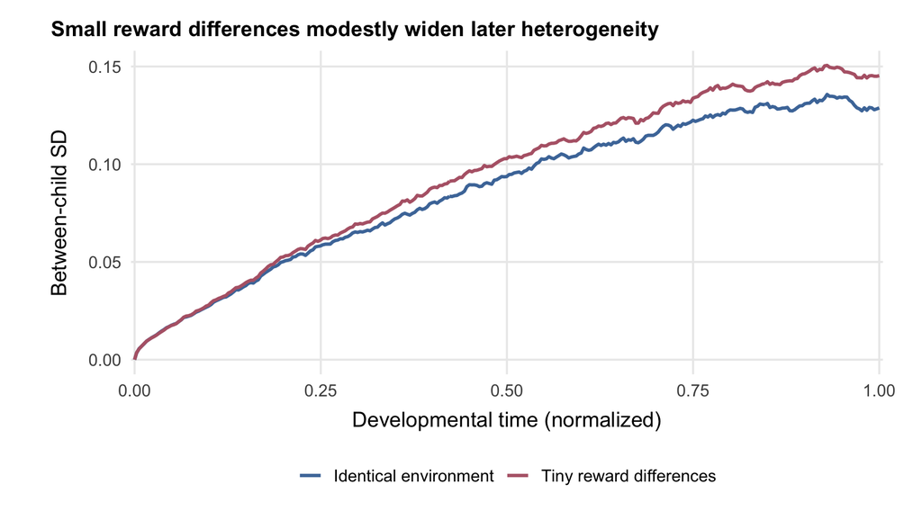

```r
context_sd <- df_context %>%
  group_by(context_condition, dev_time) %>%
  summarize(
    sd_pi = sd(pi),
    .groups = "drop"
  )

assert_plot_coverage(
  context_sd,
  group_cols = "context_condition",
  value_cols = "sd_pi"
)

ggplot(
  context_sd,
  aes(dev_time, sd_pi, color = context_condition)
) +
  geom_line(linewidth = 1.05) +
  scale_color_manual(values = condition_cols) +
  scale_dev_time() +
  theme_result() +
  labs(
    title = "Small reward differences modestly widen later heterogeneity",
    x = "Developmental time (normalized)",
    y = "Between-child SD",
    color = NULL
  )
```

The increase in spread is modest. We therefore avoid describing this result as strong *amplification*.

## Their clearer effect is on rank stability

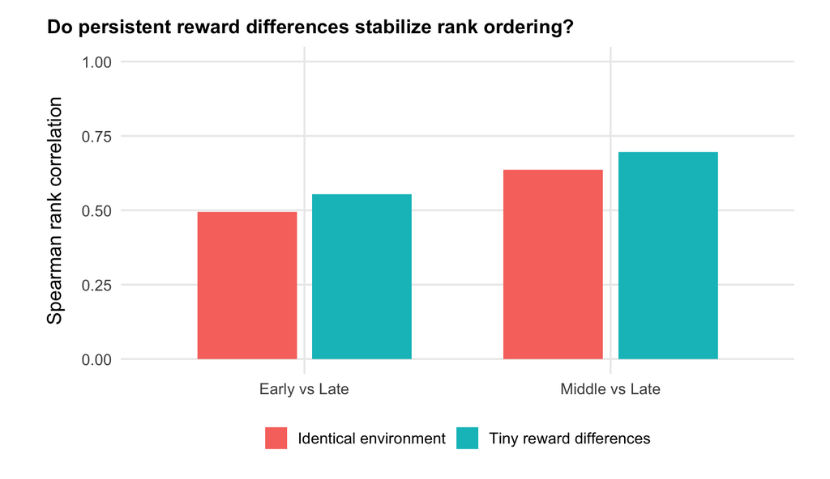

```r
context_stability_plot <- context_stability %>%
  filter(comparison %in% c("Middle vs Late", "Early vs Late"))

ggplot(
  context_stability_plot,
  aes(comparison, spearman_rho, fill = context_condition)
) +
  geom_col(position = position_dodge(width = 0.75), width = 0.65) +
  coord_cartesian(ylim = c(0, 1)) +
  theme_result() +
  labs(
    title = "Do persistent reward differences stabilize rank ordering?",
    x = NULL,
    y = "Spearman rank correlation",
    fill = NULL
  )
```

Rank-order stability with identical versus slightly different reward environments

| comparison | spearman_rho | context_condition |
| --- | --- | --- |
| Early vs Middle | 0.559 | Identical environment |
| Middle vs Late | 0.636 | Identical environment |
| Early vs Late | 0.495 | Identical environment |
| Early vs Middle | 0.602 | Tiny reward differences |
| Middle vs Late | 0.696 | Tiny reward differences |
| Early vs Late | 0.555 | Tiny reward differences |

In the current parameterization, the small persistent reward differences increase rank persistence more clearly than they increase the overall amount of spread. This suggests a useful distinction:

> **Stochastic experience creates differentiation; small persistent environmental differences can help anchor which children remain relatively high or low.**

Under persistent child-specific reward probabilities, the anchoring also has a simple long-run interpretation: $V_i^*=p_iR$, so different $p_i$ imply different long-run mean engagement regimes even when $C_{\min}$ and all capacity-related assumptions are shared.

### What Results 2 and 3 together imply

The two results separate **emergence** from **anchoring**:

- under a shared environment, stochastic experience is enough for children to diverge over development, but rank identity eventually fades;
- with small persistent environmental differences, those developmental differences can remain anchored because children approach different long-run mean engagement regimes.

This lets the model explain persistent individual differences without introducing a stable EF-capacity trait.

## Reward probability predicts later engagement

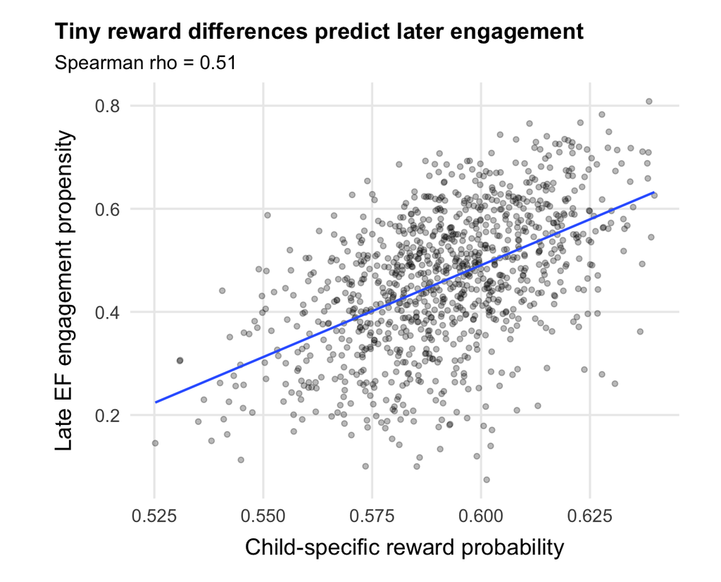

```r
late_context <- df_context_tiny %>%
  filter(dev_time >= 0.85, dev_time <= 0.95) %>%
  group_by(child_id, p_reward_child) %>%
  summarize(
    late_pi = mean(pi),
    .groups = "drop"
  )

rho_context <- cor(
  late_context$p_reward_child,
  late_context$late_pi,
  method = "spearman"
)

ggplot(
  late_context,
  aes(p_reward_child, late_pi)
) +
  geom_point(alpha = 0.28, size = 1.3) +
  geom_smooth(method = "lm", se = FALSE, linewidth = 0.7) +
  theme_result() +
  labs(
    title = "Tiny reward differences predict later engagement",
    subtitle = paste0("Spearman rho = ", round(rho_context, 2)),
    x = "Child-specific reward probability",
    y = "Late EF engagement propensity"
  )
```

# Result 4: Stress produces a mainly transient engagement dip

Stress enters the **fast control decision**, not the slow learned cost state:

$$\Delta\widehat{\mathrm{EVC}}_t
=
V_t-C_t-X_t.$$

During an acute stressor,

$$X_t\uparrow
\Rightarrow
\pi_t\downarrow.$$

There is no age-dependent growth window in this model. A lingering effect can arise only indirectly if stress suppresses engagement and therefore reduces learning/practice opportunities during that period.

```r
T_stress <- default_pars$T

stress_vec <- rep(0, T_stress)

stress_start <- round(0.60 * T_stress)
stress_end <- round(0.635 * T_stress)

stress_vec[stress_start:stress_end] <- 0.20

df_no_stress <- simulate_population(
  model = "value_cost",
  N = 1000,
  extra_cost = rep(0, T_stress),
  seed = 810
) %>%
  mutate(condition = "Reference")

df_stress <- simulate_population(
  model = "value_cost",
  N = 1000,
  extra_cost = stress_vec,
  seed = 810
) %>%
  mutate(condition = "Stress")

df_stress_all <- bind_rows(
  df_no_stress,
  df_stress
)
```

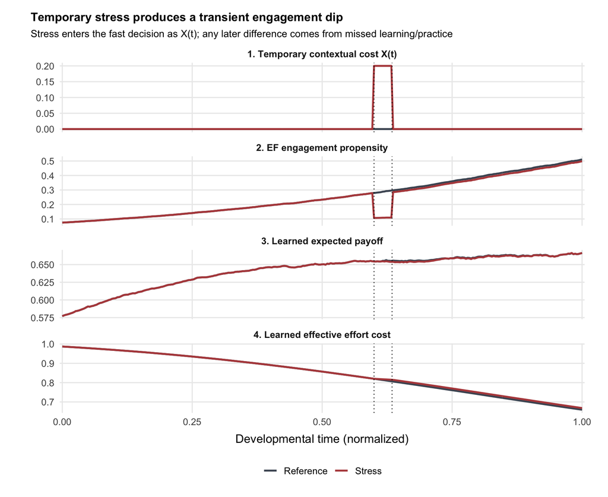

```r
stress_summary <- df_stress_all %>%
  group_by(condition, dev_time) %>%
  summarize(
    mean_X = mean(extra_cost),
    mean_pi = mean(pi),
    mean_V = mean(V),
    mean_C = mean(C),
    .groups = "drop"
  ) %>%
  pivot_longer(
    cols = c(
      mean_X,
      mean_pi,
      mean_V,
      mean_C
    ),
    names_to = "measure",
    values_to = "value"
  ) %>%
  mutate(
    measure = recode(
      measure,
      mean_X = "1. Temporary contextual cost X(t)",
      mean_pi = "2. EF engagement propensity",
      mean_V = "3. Learned expected payoff",
      mean_C = "4. Learned effective effort cost"
    )
  )

# This check prevents the kind of silent/truncated line that motivated
# the v13 figure audit.
assert_plot_coverage(
  stress_summary,
  group_cols = c("condition", "measure"),
  value_cols = "value"
)

stress_start_time <- (stress_start - 1) / (T_stress - 1)
stress_end_time <- (stress_end - 1) / (T_stress - 1)

ggplot(
  stress_summary,
  aes(dev_time, value, color = condition)
) +
  geom_line(linewidth = 1.0) +
  geom_vline(
    xintercept = c(stress_start_time, stress_end_time),
    linetype = "dotted",
    linewidth = 0.45
  ) +
  facet_wrap(~ measure, ncol = 1, scales = "free_y") +
  scale_color_manual(values = condition_cols) +
  scale_dev_time() +
  theme_result(base_size = 13) +
  labs(
    title = "Temporary stress produces a transient engagement dip",
    subtitle = "Stress enters the fast decision as X(t); any later difference comes from missed learning/practice",
    x = "Developmental time (normalized)",
    y = NULL,
    color = NULL
  )
```

## Quantifying the transient and residual effects

```r
stress_pi_diff <- df_stress_all %>%
  group_by(condition, dev_time) %>%
  summarize(mean_pi = mean(pi), .groups = "drop") %>%
  pivot_wider(names_from = condition, values_from = mean_pi) %>%
  mutate(delta_stress = Stress - Reference)

largest_stress_dip <- min(stress_pi_diff$delta_stress, na.rm = TRUE)

late_stress <- df_stress_all %>%
  filter(dev_time >= 0.85, dev_time <= 0.95) %>%
  group_by(condition) %>%
  summarize(
    late_mean_pi = mean(pi),
    .groups = "drop"
  )

late_stress_wide <- late_stress %>%
  pivot_wider(names_from = condition, values_from = late_mean_pi)

late_stress_difference <- late_stress_wide$Stress - late_stress_wide$Reference

knitr::kable(
  late_stress,
  digits = 3,
  caption = "Late engagement after a temporary stressor"
)
```

Late engagement after a temporary stressor

| condition | late_mean_pi |
| --- | --- |
| Reference | 0.450 |
| Stress | 0.437 |

The model produces a much larger engagement drop during the stress period than remains later. Under this specification, the largest mean stress-reference difference is -0.186, whereas the late difference is -0.014. The dominant pattern is therefore a **transient contextual fluctuation with a smaller residual consequence**.

# Result 5: The minimal model does not produce an early-support advantage

The previous capacity model guaranteed that early reward support mattered more because capacity growth was multiplied by an age-dependent function $g(a)$. That assumption is now removed.

We give the same reward increase for the same duration at two different developmental times:

$$p_t\uparrow
\rightarrow
\text{more rewarding engagement experiences}
\rightarrow
V_t\uparrow
\rightarrow
\pi_t\uparrow
\rightarrow
\text{more practice}
\rightarrow
C_t\downarrow.$$

If early support is intrinsically advantaged by the feedback dynamics, it should outperform later support even without an age gate.

```r
T_reward <- default_pars$T

reward_early <- rep(0, T_reward)
reward_late <- rep(0, T_reward)

duration <- round(0.13 * T_reward)
boost <- 0.12

early_start <- round(0.20 * T_reward)
late_start <- round(0.60 * T_reward)

early_end <- early_start + duration - 1
late_end <- late_start + duration - 1

reward_early[early_start:early_end] <- boost
reward_late[late_start:late_end] <- boost

df_reward_ref <- simulate_population(
  model = "value_cost",
  N = 1000,
  p_reward_shift = rep(0, T_reward),
  seed = 910
) %>%
  mutate(condition = "Reference")

df_reward_early <- simulate_population(
  model = "value_cost",
  N = 1000,
  p_reward_shift = reward_early,
  seed = 910
) %>%
  mutate(condition = "Early support")

df_reward_late <- simulate_population(
  model = "value_cost",
  N = 1000,
  p_reward_shift = reward_late,
  seed = 910
) %>%
  mutate(condition = "Later support")

df_reward_timing <- bind_rows(
  df_reward_ref,
  df_reward_early,
  df_reward_late
)
```

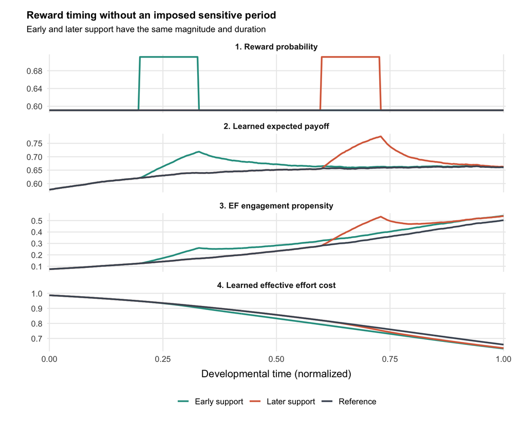

```r
reward_summary <- df_reward_timing %>%
  group_by(condition, dev_time) %>%
  summarize(
    mean_p = mean(p_reward_used),
    mean_V = mean(V),
    mean_pi = mean(pi),
    mean_C = mean(C),
    .groups = "drop"
  ) %>%
  pivot_longer(
    cols = c(mean_p, mean_V, mean_pi, mean_C),
    names_to = "measure",
    values_to = "value"
  ) %>%
  mutate(
    measure = recode(
      measure,
      mean_p = "1. Reward probability",
      mean_V = "2. Learned expected payoff",
      mean_pi = "3. EF engagement propensity",
      mean_C = "4. Learned effective effort cost"
    )
  )

assert_plot_coverage(
  reward_summary,
  group_cols = c("condition", "measure"),
  value_cols = "value"
)

ggplot(
  reward_summary,
  aes(dev_time, value, color = condition)
) +
  geom_line(linewidth = 1.0) +
  facet_wrap(~ measure, ncol = 1, scales = "free_y") +
  scale_color_manual(values = condition_cols) +
  scale_dev_time() +
  theme_result(base_size = 13) +
  labs(
    title = "Reward timing without an imposed sensitive period",
    subtitle = "Early and later support have the same magnitude and duration",
    x = "Developmental time (normalized)",
    y = NULL,
    color = NULL
  )
```

## Two fair timing comparisons

A common final-time comparison favors later interventions through recency. We therefore report both:

1. **common final developmental time**;
2. **equal lag after each intervention ends**.

```r
# Common final developmental window.
final_window <- c(0.85, 0.95)

final_scores <- df_reward_timing %>%
  filter(dev_time >= final_window[1], dev_time <= final_window[2]) %>%
  group_by(condition) %>%
  summarize(mean_pi = mean(pi), .groups = "drop")

final_ref <- final_scores$mean_pi[final_scores$condition == "Reference"]
final_early_effect <- final_scores$mean_pi[final_scores$condition == "Early support"] - final_ref
final_late_effect <- final_scores$mean_pi[final_scores$condition == "Later support"] - final_ref

# Equal lag after intervention end.
equal_lag <- round(0.15 * T_reward)
half_width <- round(0.02 * T_reward)

early_eval <- early_end + equal_lag
late_eval <- late_end + equal_lag

ref_early_lag <- score_at_steps(df_reward_ref, early_eval, half_width) %>%
  summarize(x = mean(score)) %>% pull(x)
ref_late_lag <- score_at_steps(df_reward_ref, late_eval, half_width) %>%
  summarize(x = mean(score)) %>% pull(x)

early_lag_score <- score_at_steps(df_reward_early, early_eval, half_width) %>%
  summarize(x = mean(score)) %>% pull(x)
late_lag_score <- score_at_steps(df_reward_late, late_eval, half_width) %>%
  summarize(x = mean(score)) %>% pull(x)

early_equal_lag_effect <- early_lag_score - ref_early_lag
late_equal_lag_effect <- late_lag_score - ref_late_lag

reward_effects <- tibble(
  comparison = c(
    "Same lag after support",
    "Common final time"
  ),
  `Early support effect` = c(
    early_equal_lag_effect,
    final_early_effect
  ),
  `Later support effect` = c(
    late_equal_lag_effect,
    final_late_effect
  )
)

knitr::kable(
  reward_effects,
  digits = 3,
  caption = "Reward-support effects on EF engagement propensity"
)
```

Reward-support effects on EF engagement propensity

| comparison | Early support effect | Later support effect |
| --- | --- | --- |
| Same lag after support | 0.051 | 0.053 |
| Common final time | 0.043 | 0.049 |

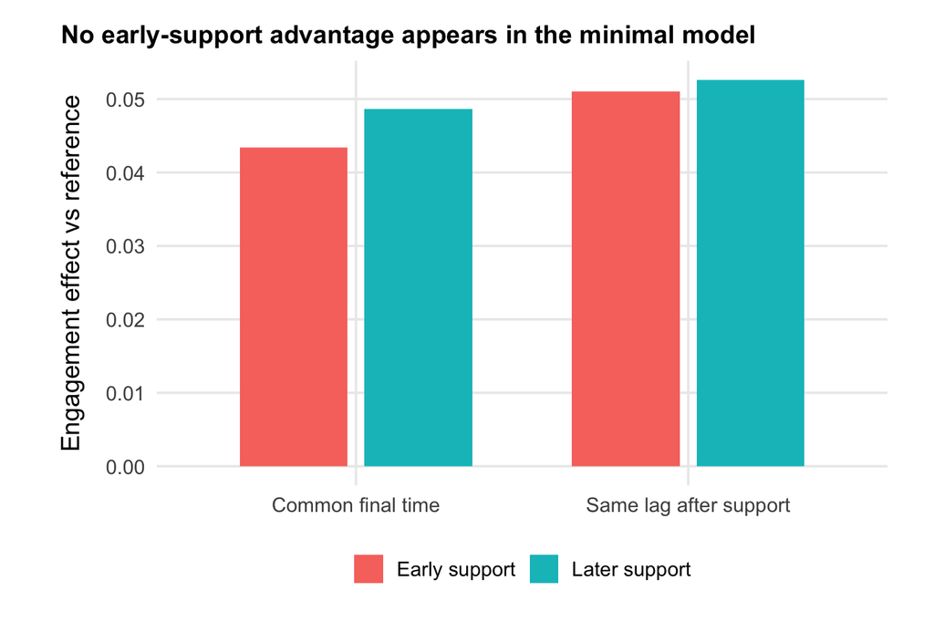

```r
reward_effect_plot <- reward_effects %>%
  pivot_longer(
    cols = c(`Early support effect`, `Later support effect`),
    names_to = "timing",
    values_to = "effect"
  ) %>%
  mutate(
    timing = recode(
      timing,
      `Early support effect` = "Early support",
      `Later support effect` = "Later support"
    )
  )

ggplot(
  reward_effect_plot,
  aes(comparison, effect, fill = timing)
) +
  geom_col(position = position_dodge(width = 0.75), width = 0.65) +
  theme_result() +
  labs(
    title = "No early-support advantage appears in the minimal model",
    x = NULL,
    y = "Engagement effect vs reference",
    fill = NULL
  )
```

Under the current specification, early support is **not** more effective than later support under either comparison. The important conclusion is therefore negative but informative:

> **Experience-dependent value and cost feedback alone does not imply an early sensitive-period advantage.**

A strong early-intervention advantage would require an additional developmental assumption, such as age-dependent plasticity. We should only add that mechanism if it is part of the theoretical claim we want to test.

# Result 6: Under a shared environment, developmental differentiation is finite-horizon

The analytic constraint predicts that the self-reinforcing dynamics should weaken as there is less left to learn. We therefore extend the same initially homogeneous population to four times the original developmental horizon.

The critical distinction is between:

- **cross-sectional heterogeneity:** how much children differ at a given time;
- **rank memory:** whether the same children remain high or low.

```r
# "4x the original horizon" means four times as many time
# intervals. A trajectory with T points contains T - 1 intervals.
T_long <- 4 * (default_pars$T - 1) + 1

df_long <- simulate_population(
  model = "value_cost",
  N = 600,
  T = T_long,
  p_reward_sd = 0,
  record_every = 10,
  seed = 1400
) %>%
  mutate(
    time_multiple = (step - 1) / (default_pars$T - 1)
  )
```

## Cross-sectional heterogeneity eventually falls

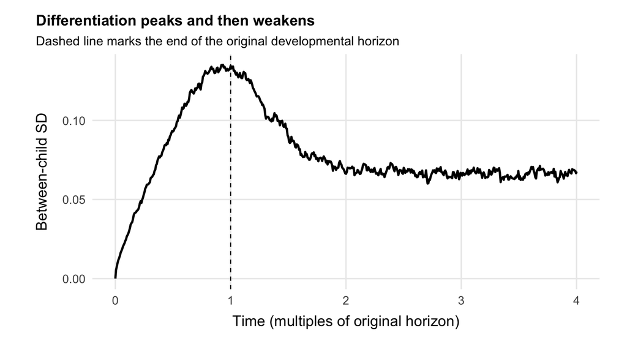

```r
long_sd <- df_long %>%
  group_by(time_multiple) %>%
  summarize(sd_pi = sd(pi), .groups = "drop")

assert_plot_coverage(
  long_sd,
  time_col = "time_multiple",
  value_cols = "sd_pi",
  expected_start = 0,
  expected_end = 4
)

ggplot(long_sd, aes(time_multiple, sd_pi)) +
  geom_line(linewidth = 1.0) +
  geom_vline(xintercept = 1, linetype = "dashed", linewidth = 0.45) +
  theme_result() +
  labs(
    title = "Differentiation peaks and then weakens",
    subtitle = "Dashed line marks the end of the original developmental horizon",
    x = "Time (multiples of original horizon)",
    y = "Between-child SD"
  )
```

The nonzero long-run SD should not be interpreted as permanent types: choices and reward outcomes remain stochastic and the learning rate is constant.

## Rank memory is the stronger diagnostic

We use each child’s mean engagement around the end of the original developmental period as a reference rank, then ask how strongly that rank predicts later ranks.

```r
reference_rank_scores <- df_long %>%
  filter(time_multiple >= 0.80, time_multiple <= 0.95) %>%
  group_by(child_id) %>%
  summarize(reference_score = mean(pi), .groups = "drop")

memory_centers <- seq(0.90, 4.00, by = 0.20)
memory_half_width <- 0.06

rank_memory <- bind_rows(
  lapply(memory_centers, function(center_i) {

    later_scores <- df_long %>%
      filter(
        time_multiple >= center_i - memory_half_width,
        time_multiple <= center_i + memory_half_width
      ) %>%
      group_by(child_id) %>%
      summarize(later_score = mean(pi), .groups = "drop")

    joined <- inner_join(reference_rank_scores, later_scores, by = "child_id")

    tibble(
      time_multiple = center_i,
      rank_memory = cor(
        joined$reference_score,
        joined$later_score,
        method = "spearman"
      )
    )
  })
)
```

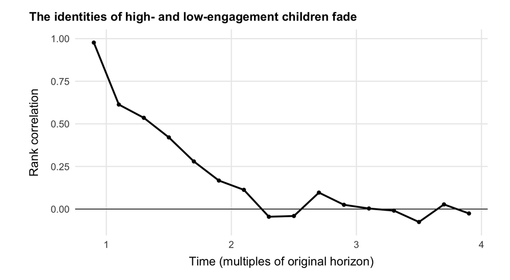

```r
ggplot(rank_memory, aes(time_multiple, rank_memory)) +
  geom_hline(yintercept = 0, linewidth = 0.4) +
  geom_line(linewidth = 1.0) +
  geom_point(size = 1.6) +
  coord_cartesian(ylim = c(-0.1, 1)) +
  theme_result() +
  labs(
    title = "The identities of high- and low-engagement children fade",
    x = "Time (multiples of original horizon)",
    y = "Rank correlation"
  )
```

This distinction clarifies the theoretical result: **early stochastic experience can generate substantial and moderately persistent developmental differentiation, but the minimal stationary model does not permanently lock individuals into high- and low-engagement types.**

This conclusion applies to the **shared-environment case**, where all children have the same stationary reward probability. Persistent between-child differences in reward environment provide a separate anchoring mechanism, as shown in Result 3.

This default trajectory answers *whether* rank memory can fade, but not **how quickly it fades across the parameter region**. Result 7 therefore extends this analysis by estimating rank-memory timescales for the same wider parameter sample used in the robustness analysis.

# Result 7: How robust is the developmental pattern?

The previous figures use one provisional parameterization. An earlier local sensitivity check suggested that the pattern was not confined to that single point, but each parameter vector was simulated only once and the range was deliberately narrow.

Here we make the test harder in two ways:

1. sample a **wider parameter region**;
2. run **multiple independent populations for every parameter vector** so stochastic realization is not confounded with parameter choice.

We vary six quantities:

- value-learning rate $\alpha_V$;
- practice/learned-efficiency rate $\alpha_C$;
- decision temperature $\tau$;
- reward probability $p$;
- initial net control value $D_0=V_0-C_0$;
- available practice headroom $H_C=C_0-C_{\min}$.

Separating $D_0$ from $H_C$ is important. Varying $C_0$ alone would change both initial net utility and how much future cost reduction is possible, so these two assumptions are varied independently here.

The parameter region is still a theoretical sensitivity region, not a claim about psychologically plausible bounds in children.

Within each parameter set, children still share the same reward probability. The sweep varies the population-level value of $p$ across parameter sets; it does **not** introduce child-specific $p_i$ differences. The long-horizon rank-memory results below therefore characterize persistence under a shared environment.

```r
log_runif <- function(n, min, max) {
  exp(runif(n, log(min), log(max)))
}

set.seed(260819)

# ------------------------------------------------------------------
# Sweep size
# ------------------------------------------------------------------
# Use quick_sweep = TRUE while developing the document.
# Set it to FALSE for the full analysis used in the final results.
quick_sweep <- FALSE

if (quick_sweep) {
  n_parameter_sets <- 80
  n_mc_reps <- 3
  sweep_N <- 100
  sweep_T <- 700
} else {
  n_parameter_sets <- 250
  n_mc_reps <- 5
  sweep_N <- 150
  sweep_T <- 900
}

sweep_pars <- tibble(
  set_id = seq_len(n_parameter_sets),

  alpha_V = log_runif(n_parameter_sets, 0.006, 0.070),
  alpha_C = log_runif(n_parameter_sets, 0.0004, 0.0070),
  tau = runif(n_parameter_sets, 0.10, 0.30),
  p_reward = runif(n_parameter_sets, 0.45, 0.72),

  # Initial net value and future practice opportunity are varied separately.
  initial_delta = runif(n_parameter_sets, -0.60, -0.20),
  cost_headroom = runif(n_parameter_sets, 0.25, 0.75),

  V0 = default_pars$V0
) %>%
  mutate(
    C0 = V0 - initial_delta,
    C_min = C0 - cost_headroom
  )

# ------------------------------------------------------------------
# Parallel execution
# ------------------------------------------------------------------
# Parallelize over parameter sets. Each worker runs the Monte Carlo
# replications for one parameter vector sequentially. This avoids the
# overhead of launching one future for every single replication.
#
# On macOS/Linux the sweep uses base R forked workers.
# Leave one physical core free for the operating system.
n_workers <- max(
  1L,
  min(
    n_parameter_sets,
    parallel::detectCores(logical = FALSE) - 1L
  )
)

# Fallback for machines where physical-core detection returns NA/1.
if (is.na(n_workers) || n_workers < 1L) n_workers <- 1L

message(
  "Parameter sweep: ",
  n_parameter_sets, " parameter sets × ",
  n_mc_reps, " replications; ",
  n_workers, " parallel workers."
)

sweep_list <- parallel_lapply(
  seq_len(n_parameter_sets),

  function(j) {

    pars_j <- sweep_pars[j, ]

    bind_rows(
      lapply(seq_len(n_mc_reps), function(mc) {

        metrics_j <- simulate_development_metrics_fast(
          N = sweep_N,
          T = sweep_T,

          V0 = pars_j$V0,
          C0 = pars_j$C0,
          C_min = pars_j$C_min,

          tau = pars_j$tau,
          p_reward = pars_j$p_reward,
          alpha_V = pars_j$alpha_V,
          alpha_C = pars_j$alpha_C,

          record_every = 10,
          seed = 100000 + j * 100 + mc
        )

        bind_cols(
          pars_j,
          tibble(mc_rep = mc),
          metrics_j
        )
      })
    )
  },

  workers = n_workers
)

sweep_rep_results <- bind_rows(sweep_list)

# Average each outcome across independent stochastic realizations.
sweep_results <- sweep_rep_results %>%
  group_by(
    set_id,
    alpha_V,
    alpha_C,
    tau,
    p_reward,
    initial_delta,
    cost_headroom,
    V0,
    C0,
    C_min
  ) %>%
  summarize(
    # Keep replication-level names intact while computing uncertainty.
    delta_mean_avg = mean(delta_mean, na.rm = TRUE),
    delta_mean_mc_sd = sd(delta_mean, na.rm = TRUE),

    sd_gain_avg = mean(sd_gain, na.rm = TRUE),
    sd_gain_mc_sd = sd(sd_gain, na.rm = TRUE),

    rho_middle_late_avg = mean(rho_middle_late, na.rm = TRUE),
    rho_middle_late_mc_sd = sd(rho_middle_late, na.rm = TRUE),

    rho_early_late_avg = mean(rho_early_late, na.rm = TRUE),

    .groups = "drop"
  ) %>%
  rename(
    delta_mean = delta_mean_avg,
    sd_gain = sd_gain_avg,
    rho_middle_late = rho_middle_late_avg,
    rho_early_late = rho_early_late_avg
  )
```

## Distribution of replicated outcomes

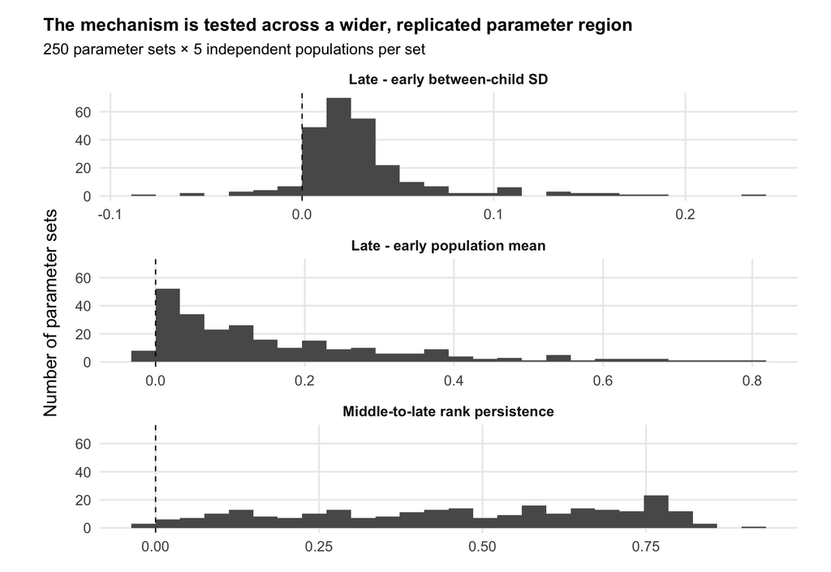

```r
sweep_plot <- sweep_results %>%
  select(delta_mean, sd_gain, rho_middle_late) %>%
  pivot_longer(
    everything(),
    names_to = "metric",
    values_to = "value"
  ) %>%
  mutate(
    metric = recode(
      metric,
      delta_mean = "Late - early population mean",
      sd_gain = "Late - early between-child SD",
      rho_middle_late = "Middle-to-late rank persistence"
    )
  )

ggplot(sweep_plot, aes(value)) +
  geom_histogram(bins = 26, boundary = 0) +
  geom_vline(xintercept = 0, linetype = "dashed", linewidth = 0.45) +
  facet_wrap(~ metric, ncol = 1, scales = "free_x") +
  theme_result() +
  labs(
    title = "The mechanism is tested across a wider, replicated parameter region",
    subtitle = paste0(
      n_parameter_sets,
      " parameter sets × ",
      n_mc_reps,
      " independent populations per set"
    ),
    x = NULL,
    y = "Number of parameter sets"
  )
```

Across the wider replicated sweep:

- 97% of parameter sets show a higher late than early population mean;
- 93% show greater late than early between-child heterogeneity;
- 90% show **both** patterns;
- median middle-to-late rank persistence is $\rho=$ 0.48.

Unlike a narrow local check, this wider analysis is allowed to fail. Parameter regions with weak development, shrinking heterogeneity, or poor rank persistence are useful because they show where the proposed mechanism is insufficient.

## How much of the result is Monte Carlo noise?

```r
mc_uncertainty <- tibble(
  outcome = c(
    "Developmental mean change",
    "Heterogeneity change",
    "Middle-to-late rank persistence"
  ),
  median_across_parameter_sets = c(
    median(sweep_results$delta_mean, na.rm = TRUE),
    median(sweep_results$sd_gain, na.rm = TRUE),
    median(sweep_results$rho_middle_late, na.rm = TRUE)
  ),
  median_within_set_mc_sd = c(
    median(sweep_results$delta_mean_mc_sd, na.rm = TRUE),
    median(sweep_results$sd_gain_mc_sd, na.rm = TRUE),
    median(sweep_results$rho_middle_late_mc_sd, na.rm = TRUE)
  )
)

knitr::kable(
  mc_uncertainty,
  digits = 3,
  caption = "Typical outcome size versus variation across stochastic replications"
)
```

Typical outcome size versus variation across stochastic replications

| outcome | median_across_parameter_sets | median_within_set_mc_sd |
| --- | --- | --- |
| Developmental mean change | 0.108 | 0.004 |
| Heterogeneity change | 0.023 | 0.003 |
| Middle-to-late rank persistence | 0.479 | 0.055 |

The replicated design separates **parameter sensitivity** from **simulation noise**. Rank persistence is expected to be noisier than the population mean because it depends on the identities and ordering of individual trajectories.

## Which assumptions matter most?

```r
parameter_names <- c(
  "alpha_V",
  "alpha_C",
  "tau",
  "p_reward",
  "initial_delta",
  "cost_headroom"
)

outcome_names <- c(
  "delta_mean",
  "sd_gain",
  "rho_middle_late"
)

parameter_associations <- bind_rows(
  lapply(parameter_names, function(p_name) {
    bind_rows(
      lapply(outcome_names, function(o_name) {
        tibble(
          parameter = p_name,
          outcome = o_name,
          spearman_rho = cor(
            sweep_results[[p_name]],
            sweep_results[[o_name]],
            method = "spearman",
            use = "complete.obs"
          )
        )
      })
    )
  })
)

knitr::kable(
  parameter_associations,
  digits = 2,
  caption = "Parameter-outcome associations across the wider replicated sweep"
)
```

Parameter-outcome associations across the wider replicated sweep

| parameter | outcome | spearman_rho |
| --- | --- | --- |
| alpha_V | delta_mean | -0.03 |
| alpha_V | sd_gain | 0.00 |
| alpha_V | rho_middle_late | -0.63 |
| alpha_C | delta_mean | 0.44 |
| alpha_C | sd_gain | 0.22 |
| alpha_C | rho_middle_late | 0.22 |
| tau | delta_mean | 0.23 |
| tau | sd_gain | -0.22 |
| tau | rho_middle_late | -0.59 |
| p_reward | delta_mean | 0.41 |
| p_reward | sd_gain | 0.05 |
| p_reward | rho_middle_late | -0.09 |
| initial_delta | delta_mean | 0.44 |
| initial_delta | sd_gain | -0.05 |
| initial_delta | rho_middle_late | -0.39 |
| cost_headroom | delta_mean | 0.30 |
| cost_headroom | sd_gain | 0.17 |
| cost_headroom | rho_middle_late | 0.09 |

These are descriptive sensitivity diagnostics, not causal effect estimates.

The quantities most strongly associated with an outcome are the assumptions we most need to justify or constrain empirically. In particular, the practice pathway is characterized not only by $\alpha_C$ but also by $H_C$, the amount of practice-related improvement that is available.

Two of the strongest associations with **rank persistence** are also theoretically informative. Faster value learning is associated with lower middle-to-late rank stability ($\rho=$ -0.63), and higher decision temperature is likewise associated with lower rank stability ($\rho=$ -0.59). In this model, faster updating toward a shared reward environment can overwrite idiosyncratic early value histories more quickly, while higher $\tau$ weakens the mapping from learned value-cost differences to behavior. Thus, mechanisms that support rapid adaptation do not necessarily stabilize individual differences; they can shorten their persistence.

The long-horizon analysis below also asks whether **available practice headroom** changes how long rank information survives, rather than only how much developmental change occurs within the original horizon.

## How finite is “finite”? Rank-memory timescales across parameter space

The default long-horizon simulation shows that rank memory eventually fades, while the finite-horizon sweep shows that $\alpha_V$ and $\tau$ are strongly related to rank stability. We now connect those results directly.

The question is not whether every stochastic trajectory converges to an identical point. Under a shared stationary environment, agents instead fluctuate around a common long-run regime. The relevant question is:

> **How long does information about an individual’s developmental rank remain predictive?**

To keep this analysis computationally manageable, we use a sweep-specific simulator that stores only window-averaged engagement scores rather than full trajectories.

```r
simulate_rank_memory_fast <- function(
  V0,
  C0,
  C_min,
  tau,
  p_reward,
  alpha_V,
  alpha_C,
  reward_mag = default_pars$reward_mag,
  N = 180,
  T0 = 900,
  horizon_multiple = 4,
  centers = seq(1, 4, by = 0.25),
  reference_window = c(0.80, 0.95),
  evaluation_half_width = 0.05,
  seed = 1
) {

  set.seed(seed)

  V <- rep(V0, N)
  C <- rep(C0, N)

  # T0 points contain T0 - 1 intervals. Use the interval scale
  # throughout so that 1x, 2x, ..., horizon_multiple are exact.
  base_intervals <- T0 - 1
  total_T <- round(horizon_multiple * base_intervals) + 1L

  ref_lo <- round(reference_window[1] * base_intervals) + 1L
  ref_hi <- round(reference_window[2] * base_intervals) + 1L

  center_steps <- round(centers * base_intervals) + 1L
  half_width <- max(
    1L,
    round(evaluation_half_width * base_intervals)
  )

  ref_sum <- numeric(N)
  ref_n <- 0L

  score_sums <- matrix(
    0,
    nrow = N,
    ncol = length(centers)
  )
  score_n <- integer(length(centers))

  for (tt in seq_len(total_T)) {

    pi_engage <- plogis((V - C) / tau)

    if (tt >= ref_lo && tt <= ref_hi) {
      ref_sum <- ref_sum + pi_engage
      ref_n <- ref_n + 1L
    }

    active_windows <- which(
      abs(tt - center_steps) <= half_width
    )

    if (length(active_windows) > 0) {
      for (kk in active_windows) {
        score_sums[, kk] <- score_sums[, kk] + pi_engage
        score_n[kk] <- score_n[kk] + 1L
      }
    }

    A <- as.integer(runif(N) < pi_engage)
    reward_success <- as.integer(runif(N) < p_reward)
    reward_observed <- A * reward_success * reward_mag

    V <- V + alpha_V * A * (reward_observed - V)
    C <- C - alpha_C * A * (C - C_min)

    V <- clip(V, lo = 0, hi = reward_mag)
    C <- pmax(C, C_min)
  }

  reference_score <- ref_sum / ref_n

  rank_memory <- vapply(
    seq_along(centers),
    function(kk) {
      later_score <- score_sums[, kk] / score_n[kk]
      suppressWarnings(
        cor(
          reference_score,
          later_score,
          method = "spearman"
        )
      )
    },
    numeric(1)
  )

  tibble(
    time_multiple = centers,
    rank_memory = rank_memory
  )
}

rank_memory_metrics <- function(curve_df) {

  curve_df <- curve_df %>%
    arrange(time_multiple)

  t <- curve_df$time_multiple
  r <- curve_df$rank_memory

  positive_r <- pmax(r, 0)

  memory_auc <- sum(
    diff(t) *
      (head(positive_r, -1) + tail(positive_r, -1)) / 2
  ) / (max(t) - min(t))

  get_nearest <- function(target) {
    r[which.min(abs(t - target))]
  }

  below_20 <- which(
    t >= 1 & r < 0.20
  )

  tibble(
    memory_auc = memory_auc,
    rho_2x = get_nearest(2),
    rho_3x = get_nearest(3),
    first_below_20 = if (
      length(below_20) > 0
    ) {
      t[min(below_20)]
    } else {
      NA_real_
    }
  )
}
```

```r
long_memory_N <- if (quick_sweep) 100 else 180

long_workers <- max(
  1L,
  min(
    n_parameter_sets,
    parallel::detectCores(logical = FALSE) - 1L
  )
)

if (is.na(long_workers) || long_workers < 1L) {
  long_workers <- 1L
}

long_memory_list <- parallel_lapply(
  seq_len(n_parameter_sets),

  function(j) {

    pars_j <- sweep_pars[j, ]

    curve_j <- simulate_rank_memory_fast(
      V0 = pars_j$V0,
      C0 = pars_j$C0,
      C_min = pars_j$C_min,
      tau = pars_j$tau,
      p_reward = pars_j$p_reward,
      alpha_V = pars_j$alpha_V,
      alpha_C = pars_j$alpha_C,
      N = long_memory_N,
      T0 = sweep_T,
      seed = 300000 + j
    )

    curve_j %>%
      mutate(set_id = pars_j$set_id)
  },

  workers = long_workers
)

long_memory_curves <- bind_rows(
  long_memory_list
)

long_memory_metrics_df <- long_memory_curves %>%
  group_by(set_id) %>%
  group_modify(
    ~ rank_memory_metrics(.x)
  ) %>%
  ungroup() %>%
  left_join(
    sweep_pars,
    by = "set_id"
  )
```

### Rank memory fades at different rates

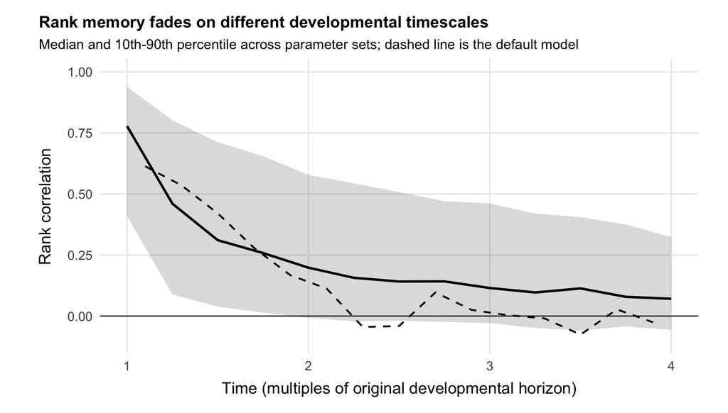

```r
long_memory_band <- long_memory_curves %>%
  group_by(time_multiple) %>%
  summarize(
    q10 = quantile(rank_memory, 0.10, na.rm = TRUE),
    median = median(rank_memory, na.rm = TRUE),
    q90 = quantile(rank_memory, 0.90, na.rm = TRUE),
    .groups = "drop"
  )

ggplot(
  long_memory_band,
  aes(time_multiple, median)
) +
  geom_ribbon(
    aes(ymin = q10, ymax = q90),
    alpha = 0.18
  ) +
  geom_hline(
    yintercept = 0,
    linewidth = 0.4
  ) +
  geom_line(
    linewidth = 1.0
  ) +
  geom_line(
    data = rank_memory %>%
      filter(time_multiple >= 1),
    aes(
      x = time_multiple,
      y = rank_memory
    ),
    inherit.aes = FALSE,
    linetype = "dashed",
    linewidth = 0.75
  ) +
  coord_cartesian(
    xlim = c(1, 4),
    ylim = c(-0.10, 1)
  ) +
  theme_result() +
  labs(
    title = "Rank memory fades on different developmental timescales",
    subtitle = "Median and 10th-90th percentile across parameter sets; dashed line is the default model",
    x = "Time (multiples of original developmental horizon)",
    y = "Rank correlation"
  )
```

The model therefore makes a more precise claim than “differences are temporary”: the **duration** of rank persistence is itself a property of the learning and decision dynamics.

### Which parameters prolong rank memory?

```r
long_memory_parameters <- c(
  "alpha_V",
  "alpha_C",
  "tau",
  "p_reward",
  "initial_delta",
  "cost_headroom"
)

long_memory_associations <- bind_rows(
  lapply(
    long_memory_parameters,
    function(p_name) {
      tibble(
        parameter = p_name,
        spearman_rho_with_memory_auc = cor(
          long_memory_metrics_df[[p_name]],
          long_memory_metrics_df$memory_auc,
          method = "spearman",
          use = "complete.obs"
        )
      )
    }
  )
)

knitr::kable(
  long_memory_associations,
  digits = 2,
  caption = "Parameter associations with long-horizon rank-memory persistence"
)
```

Parameter associations with long-horizon rank-memory persistence

| parameter | spearman_rho_with_memory_auc |
| --- | --- |
| alpha_V | -0.46 |
| alpha_C | -0.08 |
| tau | -0.60 |
| p_reward | -0.14 |
| initial_delta | -0.37 |
| cost_headroom | 0.13 |

For the two parameters already highlighted by the finite-horizon analysis, the long-horizon association with rank-memory AUC is $\rho=$ -0.46 for $\alpha_V$ and $\rho=$ -0.6 for $\tau$. These values test whether the same learning and decision parameters that influence middle-to-late stability also determine **how long** developmental rank information survives.

Available practice headroom shows a smaller positive association with rank-memory persistence ($\rho=$ 0.13). This is consistent with the idea that when more practice-related cost reduction remains possible, engagement histories can continue to differentiate trajectories for longer before the practice process saturates. Because the association is modest, we treat it as a suggestive model pattern rather than a dominant determinant of persistence.

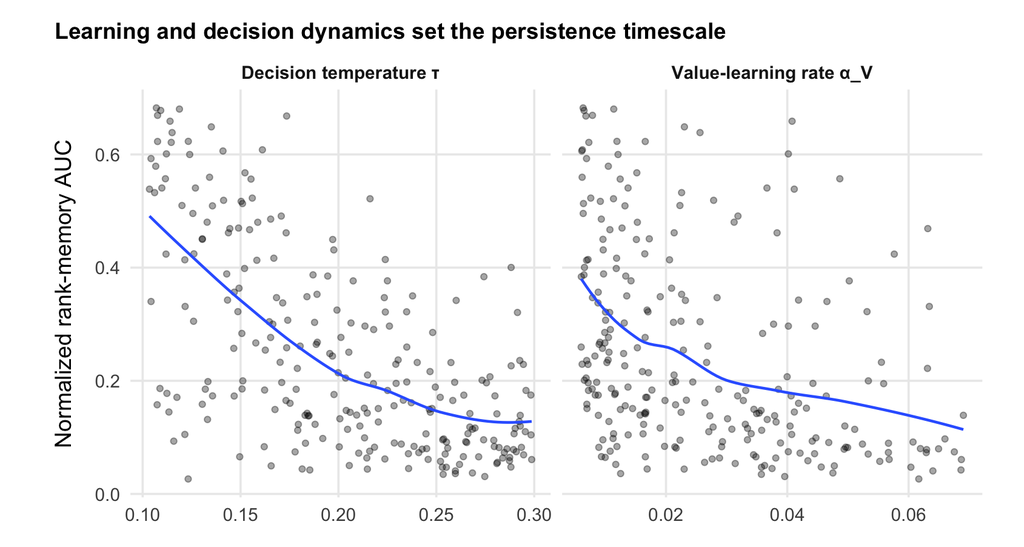

```r
long_memory_key <- bind_rows(
  long_memory_metrics_df %>%
    transmute(
      parameter = "Value-learning rate α_V",
      parameter_value = alpha_V,
      memory_auc = memory_auc
    ),
  long_memory_metrics_df %>%
    transmute(
      parameter = "Decision temperature τ",
      parameter_value = tau,
      memory_auc = memory_auc
    )
)

ggplot(
  long_memory_key,
  aes(parameter_value, memory_auc)
) +
  geom_point(
    alpha = 0.35,
    size = 1.5
  ) +
  geom_smooth(
    method = "loess",
    se = FALSE,
    linewidth = 0.8
  ) +
  facet_wrap(
    ~ parameter,
    scales = "free_x"
  ) +
  theme_result() +
  labs(
    title = "Learning and decision dynamics set the persistence timescale",
    x = NULL,
    y = "Normalized rank-memory AUC"
  )
```

This analysis connects the single-parameter long-horizon result to the wider robustness analysis. The important developmental question is therefore not whether rank ordering is permanent, but **whether its persistence timescale is long relative to the developmental period of interest**.

## Where does the developmental pattern fail?

A robustness percentage is easier to interpret if we also inspect the parameter regions that **do not** produce the target pattern.

We classify each parameter set according to whether it produces:

- developmental improvement: $\Delta\bar\pi>0$;
- increased heterogeneity: $\Delta SD(\pi)>0$.

```r
sweep_patterns <- sweep_results %>%
  mutate(
    pattern = case_when(
      delta_mean > 0 & sd_gain > 0 ~ "Improvement + differentiation",
      delta_mean > 0 & sd_gain <= 0 ~ "Improvement only",
      delta_mean <= 0 & sd_gain > 0 ~ "Differentiation only",
      TRUE ~ "Neither"
    ),
    pattern = factor(
      pattern,
      levels = c(
        "Improvement + differentiation",
        "Improvement only",
        "Differentiation only",
        "Neither"
      )
    )
  )

pattern_counts <- sweep_patterns %>%
  count(pattern, .drop = FALSE) %>%
  mutate(proportion = n / sum(n))

knitr::kable(
  pattern_counts,
  digits = 3,
  caption = "Qualitative outcomes across the wider replicated parameter sweep"
)
```

Qualitative outcomes across the wider replicated parameter sweep

| pattern | n | proportion |
| --- | --- | --- |
| Improvement + differentiation | 225 | 0.900 |
| Improvement only | 17 | 0.068 |
| Differentiation only | 8 | 0.032 |
| Neither | 0 | 0.000 |

```r
pattern_parameter_summary <- sweep_patterns %>%
  group_by(pattern) %>%
  summarize(
    n = n(),
    alpha_V = median(alpha_V),
    alpha_C = median(alpha_C),
    tau = median(tau),
    p_reward = median(p_reward),
    initial_delta = median(initial_delta),
    cost_headroom = median(cost_headroom),
    rho_middle_late = median(rho_middle_late, na.rm = TRUE),
    .groups = "drop"
  )

knitr::kable(
  pattern_parameter_summary,
  digits = 3,
  caption = "Median parameter values in success and failure regions"
)
```

Median parameter values in success and failure regions

| pattern | n | alpha_V | alpha_C | tau | p_reward | initial_delta | cost_headroom | rho_middle_late |
| --- | --- | --- | --- | --- | --- | --- | --- | --- |
| Improvement + differentiation | 225 | 0.021 | 0.002 | 0.201 | 0.587 | -0.401 | 0.504 | 0.504 |
| Improvement only | 17 | 0.036 | 0.003 | 0.216 | 0.667 | -0.227 | 0.595 | 0.135 |
| Differentiation only | 8 | 0.049 | 0.001 | 0.174 | 0.474 | -0.470 | 0.356 | 0.412 |

The purpose of this table is not to define a sharp phase boundary from a limited random sample. It identifies the kinds of conditions under which the developmental account becomes weak.

In the full sweep, the two failure patterns are qualitatively different. **Improvement-only** configurations tend to begin in more favorable conditions, with higher reward probability and a less negative initial value-cost difference; the population can therefore move upward relatively uniformly without preserving much rank structure. **Differentiation-only** configurations tend to combine lower reward probability, weaker practice learning, smaller practice headroom, and a less favorable initial value-cost difference; stochastic histories can separate children even though the population as a whole does not improve much.

This suggests an important model distinction: **developmental improvement and developmental differentiation are not the same phenomenon.** Relatively supportive conditions can produce broad improvement without strong stabilization of individual differences, whereas harsher/weak-learning conditions can permit differentiation without normative improvement. These are descriptive implications of the model, not empirical claims about children.

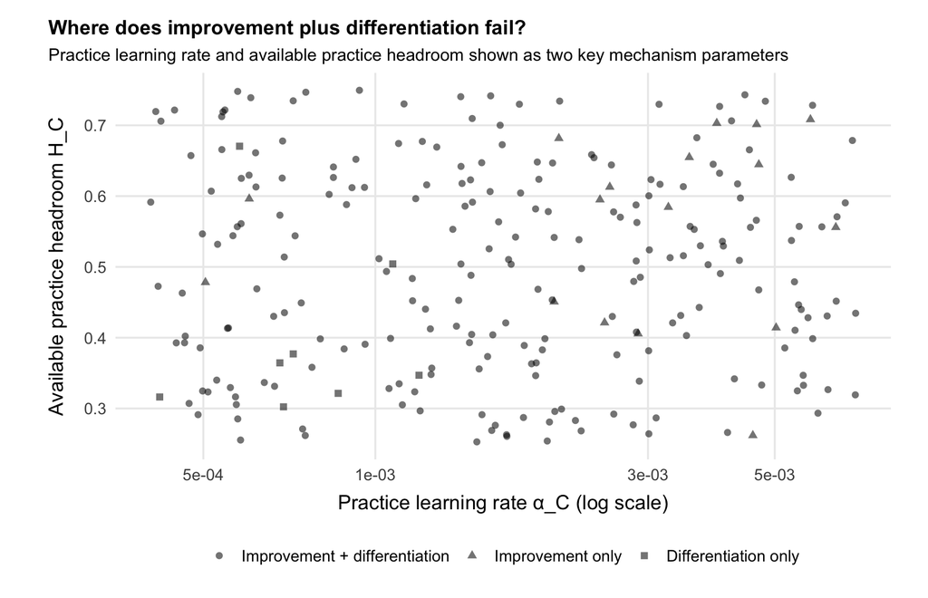

```r
ggplot(
  sweep_patterns,
  aes(alpha_C, cost_headroom, shape = pattern)
) +
  geom_point(alpha = 0.55, size = 2.0) +
  scale_x_log10() +
  theme_result() +
  labs(
    title = "Where does improvement plus differentiation fail?",
    subtitle = "Practice learning rate and available practice headroom shown as two key mechanism parameters",
    x = "Practice learning rate α_C (log scale)",
    y = "Available practice headroom H_C",
    shape = NULL
  )
```

This is a diagnostic view of the sampled parameter region. It should not be interpreted as an empirical developmental phase diagram.

## Direct check of the practice mechanism

Because the theoretical result depends on practice changing future ease of control, it is useful to visualize that dependency directly.

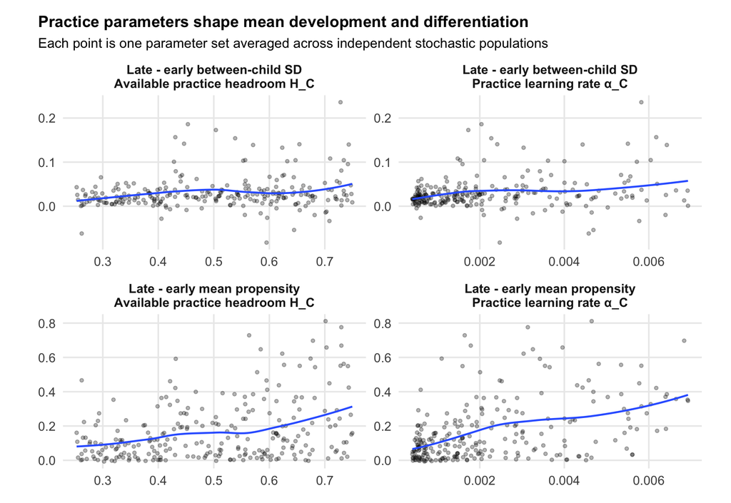

```r
practice_sensitivity <- bind_rows(
  sweep_results %>%
    transmute(
      parameter = "Practice learning rate α_C",
      parameter_value = alpha_C,
      developmental_change = delta_mean,
      heterogeneity_change = sd_gain
    ),
  sweep_results %>%
    transmute(
      parameter = "Available practice headroom H_C",
      parameter_value = cost_headroom,
      developmental_change = delta_mean,
      heterogeneity_change = sd_gain
    )
) %>%
  pivot_longer(
    cols = c(developmental_change, heterogeneity_change),
    names_to = "outcome",
    values_to = "outcome_value"
  ) %>%
  mutate(
    outcome = recode(
      outcome,
      developmental_change = "Late - early mean propensity",
      heterogeneity_change = "Late - early between-child SD"
    )
  )

practice_sensitivity <- practice_sensitivity %>%
  mutate(
    panel = paste(
      outcome,
      parameter,
      sep = "\n"
    )
  )

ggplot(
  practice_sensitivity,
  aes(parameter_value, outcome_value)
) +
  geom_point(alpha = 0.30, size = 1.2) +
  geom_smooth(method = "loess", se = FALSE, linewidth = 0.8) +
  facet_wrap(~ panel, ncol = 2, scales = "free") +
  theme_result() +
  labs(
    title = "Practice parameters shape mean development and differentiation",
    subtitle = "Each point is one parameter set averaged across independent stochastic populations",
    x = NULL,
    y = NULL
  )
```

This plot should be read as a mechanism diagnostic, not evidence that these parameters have empirical values in any particular range.

# What have we learned from the minimal model?

The analyses can be summarized as a sequence of theoretical tests.

| Test | Result in the current model | Interpretation |
| --- | --- | --- |
| **EVC-like choice only** | No developmental change | A decision rule alone does not generate development. |
| **+ learned reward value** | Modest increase in mean engagement and heterogeneity | Reward learning contributes, but is not the main developmental driver under the current specification. |
| **+ practice feedback** | Stronger developmental improvement and differentiation | Practice-related change in future ease of control is the main reinforcing mechanism. |
| **Initially identical agents** | Population spreads out; ranks are moderately persistent | Stochastic experience can generate developmental differentiation without initial capacity differences. |
| **Tiny persistent reward differences** | Modest increase in spread; clearer increase in rank persistence; different long-run mean regimes | Stable environmental differences can anchor who remains relatively high or low without capacity differences. |
| **Temporary stress** | Large acute dip, much smaller late residual | Context can create transient EF fluctuations without a capacity change. |
| **Early vs later reward support** | No early-support advantage at equal post-intervention lag | The minimal feedback does not imply a sensitive period. |
| **Long horizon, shared environment (default point)** | Heterogeneity weakens and rank memory fades | Without persistent environmental differences, differentiation is developmentally persistent but not permanently locked in. |
| **Long horizon, shared environment (parameter space)** | Rank memory fades at different rates | Stability is a timescale property; learning and decision parameters determine how long rank information remains predictive. |
| **Wider replicated parameter region** | Most, but not all, parameter sets produce improvement + differentiation | The phenomenon is not confined to one tuned parameter point, and failure regions identify important constraints. |

The central theoretical claim is therefore narrower than “experience always creates stable EF types”:

> **Repeated control decisions can create substantial developmental differentiation because engagement changes later learning opportunities. This differentiation is strongest while there is still value or practice learning left to occur, can be partly anchored by persistent environmental differences, and weakens as learning saturates.**

# Extension A: Is passive cost stabilization needed?

Yuko previously asked whether a baseline cost level and mean reversion are necessary. We therefore keep this as an **extension**, not part of the core model.

The extension adds

$$C_{t+1}
=
C_t
+
\eta_C(C_{\mathrm{set}}-C_t)
-
\alpha_C A_t(C_t-C_{\min}).$$

This is different from the discarded rule $A_t=0\Rightarrow C_{t+1}>C_t$: non-engagement is not itself assigned a penalty. Instead, practice-related cost reductions partly decay unless they are reinforced.

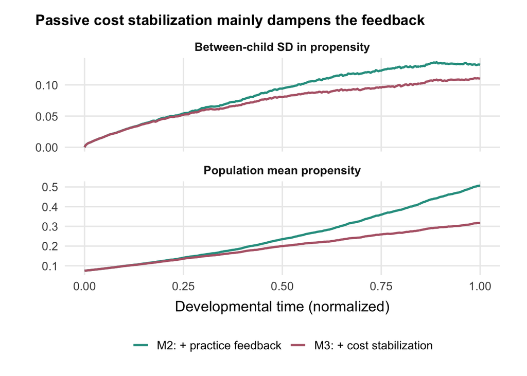

```r
df_practice_only <- simulate_population(
  model = "value_cost",
  N = 1000,
  p_reward_sd = 0,
  seed = 1201
)

df_cost_stabilized <- simulate_population(
  model = "value_cost_stabilized",
  N = 1000,
  p_reward_sd = 0,
  seed = 1201
)

diag_stabilization <- bind_rows(
  df_practice_only,
  df_cost_stabilized
) %>%
  group_by(model_label, dev_time) %>%
  summarize(
    mean_pi = mean(pi),
    sd_pi = sd(pi),
    .groups = "drop"
  ) %>%
  pivot_longer(
    cols = c(mean_pi, sd_pi),
    names_to = "measure",
    values_to = "value"
  ) %>%
  mutate(
    measure = recode(
      measure,
      mean_pi = "Population mean propensity",
      sd_pi = "Between-child SD in propensity"
    )
  )

ggplot(
  diag_stabilization,
  aes(dev_time, value, color = model_label)
) +
  geom_line(linewidth = 1.0) +
  facet_wrap(~ measure, ncol = 1, scales = "free_y") +
  scale_color_manual(values = model_cols) +
  theme_result() +
  labs(
    title = "Passive cost stabilization mainly dampens the feedback",
    x = "Developmental time (normalized)",
    y = NULL,
    color = NULL
  )
```

Under the current parameterization, this extension dampens both mean developmental change and heterogeneity. It is therefore **not needed to produce the core finite-horizon result**. We should leave it outside the main model unless a clearer theoretical or empirical reason for passive cost stabilization emerges.

# LEVC and observed performance: when a separate automaticity state becomes necessary

The reparameterization above changes how we should think about the LEVC extension.

For an **engagement-only** model, a separate automaticity state is mathematically redundant with the current practice-dependent cost state. We can write

$$L_{t+1}
=
L_t+\alpha_C A_t(1-L_t)$$

and

$$C_t
=
C_{\min}
+
H_C(1-L_t).$$

Adding both $L_t$ and $C_t$ would therefore add notation without adding a new mechanism.

A distinct automaticity state becomes useful when we want to model **observed EF task performance**. LEVC explicitly treats accuracy as a joint function of automaticity and control intensity. In a developmental extension, we could therefore distinguish:

$$\text{propensity to engage control}$$

from

$$\text{task-specific automaticity}$$

and let observed performance depend on both:

$$P(\mathrm{correct})
=
f(\text{control allocated},L_t,\text{task difficulty}).$$

This allows an important developmental possibility:

$$L_t\uparrow
\Rightarrow
\text{equal or better performance with less control}.$$

If we take this route, $C_t$ should no longer silently duplicate automaticity. We would need to decide whether $C$ represents an **inherent subjective cost of control intensity**, while $L$ represents learned task efficiency.

That is a different model and should only be introduced if the target phenomenon is observed EF **performance**, rather than the decision to engage control.

# Current interpretation

The current analyses support a more specific account than the earlier capacity-based model.

## 1. The practice pathway has a clearer reduced-form interpretation

The strongest developmental differentiation appears when actual engagement changes the future ease of control.

The original cost equation can be re-expressed exactly as a bounded practice-accumulation process:

$$\text{engage}
\rightarrow
\text{practice / learned-efficiency accumulation}
\rightarrow
\text{lower effective future effort}
\rightarrow
\text{greater future engagement}.$$

This is close in spirit to LEVC’s assumption that task experience increases automaticity and reduces the control needed for equivalent performance, but our model is a reduced-form developmental extension rather than an implementation of LEVC.

## 2. Value learning alone is not doing most of the developmental work

Learning whether EF pays off changes future engagement, but under the current model the much stronger developmental feedback comes from practice changing future ease of engagement.

That makes the practice/learned-efficiency mechanism the central theoretical assumption to constrain.

## 3. Initially identical children can become substantially different

Stochastic engagement and reward histories are enough to broaden the population distribution over a developmental horizon. The resulting rank ordering is moderately persistent, not fixed.

## 4. Small persistent environmental differences can anchor those differences

A narrow distribution of reward probabilities only modestly increases total spread, but it can increase rank persistence and predict later engagement. This is closer to a **stabilization/anchoring** result than a dramatic amplification result.

## 5. Temporary stress mainly produces a temporary EF-engagement dip

A smaller residual effect can remain through missed learning and practice opportunities. No age-sensitive capacity window is needed for this pattern.

## 6. The minimal feedback does not create an early sensitive period

Equal early and later reward support do not show an early-support advantage. A strong timing effect would therefore require an additional developmental mechanism rather than following automatically from experience-dependent feedback.

## 7. Developmental differentiation is self-limiting

The net-value equation

$$\mathbb{E}[\Delta D_t]
=
\pi_t H_t$$

makes the reason explicit. While there is value or practice learning left to occur, children who engage more receive more updates and can move farther ahead. As the learning headroom $H_t$ shrinks, that reinforcing advantage weakens.

Over a longer stationary horizon, cross-sectional heterogeneity decreases and rank memory fades. Across the wider parameter region, however, the **rate of that decay varies**. Stability in this model is therefore best understood as a timescale-relative property: differences can be persistent over a developmental period without representing permanently distinct attractors.

## 8. The robustness question is now separated from Monte Carlo noise

The wider parameter analysis averages several independent populations for each parameter vector and varies initial net value separately from available practice headroom.

This tells us more clearly whether the phenomenon belongs to a region of the model rather than to one stochastic run or one hand-selected parameter point.

# What this model does not yet establish

These simulations are theoretical demonstrations. They do not show that:

- generalized EF practice in children actually behaves like task-specific automaticity in LEVC;
- the proposed mapping from practice to effective subjective cost is the true developmental mechanism;
- the current parameter ranges correspond to children or to any particular age range;
- observed EF task scores directly measure engagement propensity;
- reward probability is the only or primary environmental source of individual differences;
- the current dynamics are uniquely supported relative to alternative control-learning models.

The replicated parameter analysis tests sensitivity of the mechanism, not empirical validity. Developmental or experimental data would still be required to constrain the learning rates, practice headroom, environmental inputs, and mapping from latent engagement to observed EF behavior.

# Recommended next steps

1. **Decide what the practice state represents psychologically.** The model only requires a saturating practice-related change in future ease of engagement. If we interpret this as generalized EF automaticity or efficiency, we need to justify transfer across contexts because LEVC itself is task-specific.
2. **Keep the reduced-form $C$ representation for now.** Adding a separate automaticity node would be mathematically redundant unless we also model EF performance.
3. **Check a more canonical LVOC value-learning implementation.** The current delta rule captures the basic experience-learning idea but not LVOC’s full feature-based value approximation.
4. **Only add age-dependent plasticity if we explicitly want to explain an early-intervention advantage.** The current feedback does not generate one by itself.
5. **Use candidate longitudinal or experimental data to constrain the mechanisms only after the engagement-versus-performance target is settled.**

# Working interpretation for the paper

A framing consistent with the current model is:

> Existing theories explain how people allocate cognitive control and how experience changes the future value or efficiency of control. We ask what these processes imply when repeated over developmental timescales. In a minimal model, stochastic experience can generate substantial and moderately persistent differentiation in EF engagement even when agents begin identically. The key reinforcing mechanism is practice: engaging control creates more opportunities for experience-dependent improvement, which can make future engagement easier and therefore more likely. Small persistent environmental differences can anchor relative differences across individuals by sustaining different long-run mean engagement regimes. Under a shared environment, the feedback is self-limiting as learning opportunities are exhausted, and the timescale over which rank differences fade depends on the learning and decision parameters. The same feedback does not by itself create an early sensitive-period advantage.

A stronger empirical claim would require evidence that the practice-to-effective-cost mechanism generalizes across the EF contexts relevant to development.

# References

- Shenhav, A., Botvinick, M. M., & Cohen, J. D. (2013). *The expected value of control: An integrative theory of anterior cingulate cortex function*. Neuron, 79, 217-240.
- Lieder, F., Shenhav, A., Musslick, S., & Griffiths, T. L. (2018). *Rational metareasoning and the plasticity of cognitive control*. PLOS Computational Biology, 14, e1006043.
- Masís, J. A., Musslick, S., & Cohen, J. D. (2021). *The Value of Learning and Cognitive Control Allocation*. Proceedings of the Annual Meeting of the Cognitive Science Society.
- Masís Obando, J. A., Musslick, S., & Cohen, J. D. (2025). *Learning expectations shape cognitive control allocation*. Proceedings of the National Academy of Sciences, 122(44), e2416720122.
- Bustamante, L., Lieder, F., Musslick, S., Shenhav, A., & Cohen, J. D. (2021). *Learning to Overexert Cognitive Control in a Stroop Task*. Cognitive, Affective, & Behavioral Neuroscience, 21, 453-471.